# Loan Data Exploration

## by [AbdElrhman Mohamed](https://www.linkedin.com/in/abdelrhman-m/)

## Preliminary Wrangling

> [Prosper](https://www.prosper.com/about) was founded in 2005 as the first peer-to-peer lending marketplace in the United States. Since then, Prosper has facilitated more than **\$14 billion** in loans to more than **890,000** people.

> Through Prosper, people can invest in each other in a way that is financially and socially rewarding. Borrowers apply online for a fixed-rate, fixed-term loan between **\$2,000** and **$40,000**. Individuals and institutions can invest in the loans and earn attractive returns. Prosper handles all loan servicing on behalf of the matched borrowers and investors.

```python
# import all packages and set plots to be embedded inline
import numpy as np
import pandas as pd
import matplotlib.pyplot as plt
import seaborn as sns
%matplotlib inline

sns.set()
```

> Load in your dataset and describe its properties through the questions below. Try and motivate your exploration goals through this section.

```python
# load in the dataset into a pandas dataframe, print statistics
loan =  pd.read_csv('prosperLoanData.csv')
```

```python
loan.shape
```

```
(113937, 81)
```

```python
loan.head()
```

|  | ListingKey | ListingNumber | ListingCreationDate | CreditGrade | Term | LoanStatus | ClosedDate | BorrowerAPR | BorrowerRate | LenderYield | ... | LP_ServiceFees | LP_CollectionFees | LP_GrossPrincipalLoss | LP_NetPrincipalLoss | LP_NonPrincipalRecoverypayments | PercentFunded | Recommendations | InvestmentFromFriendsCount | InvestmentFromFriendsAmount | Investors |
| --- | --- | --- | --- | --- | --- | --- | --- | --- | --- | --- | --- | --- | --- | --- | --- | --- | --- | --- | --- | --- | --- |
| 0 | 1021339766868145413AB3B | 193129 | 2007-08-26 19:09:29.263000000 | C | 36 | Completed | 2009-08-14 00:00:00 | 0.16516 | 0.1580 | 0.1380 | ... | -133.18 | 0.0 | 0.0 | 0.0 | 0.0 | 1.0 | 0 | 0 | 0.0 | 258 |
| 1 | 10273602499503308B223C1 | 1209647 | 2014-02-27 08:28:07.900000000 | NaN | 36 | Current | NaN | 0.12016 | 0.0920 | 0.0820 | ... | 0.00 | 0.0 | 0.0 | 0.0 | 0.0 | 1.0 | 0 | 0 | 0.0 | 1 |
| 2 | 0EE9337825851032864889A | 81716 | 2007-01-05 15:00:47.090000000 | HR | 36 | Completed | 2009-12-17 00:00:00 | 0.28269 | 0.2750 | 0.2400 | ... | -24.20 | 0.0 | 0.0 | 0.0 | 0.0 | 1.0 | 0 | 0 | 0.0 | 41 |
| 3 | 0EF5356002482715299901A | 658116 | 2012-10-22 11:02:35.010000000 | NaN | 36 | Current | NaN | 0.12528 | 0.0974 | 0.0874 | ... | -108.01 | 0.0 | 0.0 | 0.0 | 0.0 | 1.0 | 0 | 0 | 0.0 | 158 |
| 4 | 0F023589499656230C5E3E2 | 909464 | 2013-09-14 18:38:39.097000000 | NaN | 36 | Current | NaN | 0.24614 | 0.2085 | 0.1985 | ... | -60.27 | 0.0 | 0.0 | 0.0 | 0.0 | 1.0 | 0 | 0 | 0.0 | 20 |

5 rows × 81 columns

```python
#the first 11 columns
loan.head().iloc[:,:11]
```

|  | ListingKey | ListingNumber | ListingCreationDate | CreditGrade | Term | LoanStatus | ClosedDate | BorrowerAPR | BorrowerRate | LenderYield | EstimatedEffectiveYield |
| --- | --- | --- | --- | --- | --- | --- | --- | --- | --- | --- | --- |
| 0 | 1021339766868145413AB3B | 193129 | 2007-08-26 19:09:29.263000000 | C | 36 | Completed | 2009-08-14 00:00:00 | 0.16516 | 0.1580 | 0.1380 | NaN |
| 1 | 10273602499503308B223C1 | 1209647 | 2014-02-27 08:28:07.900000000 | NaN | 36 | Current | NaN | 0.12016 | 0.0920 | 0.0820 | 0.07960 |
| 2 | 0EE9337825851032864889A | 81716 | 2007-01-05 15:00:47.090000000 | HR | 36 | Completed | 2009-12-17 00:00:00 | 0.28269 | 0.2750 | 0.2400 | NaN |
| 3 | 0EF5356002482715299901A | 658116 | 2012-10-22 11:02:35.010000000 | NaN | 36 | Current | NaN | 0.12528 | 0.0974 | 0.0874 | 0.08490 |
| 4 | 0F023589499656230C5E3E2 | 909464 | 2013-09-14 18:38:39.097000000 | NaN | 36 | Current | NaN | 0.24614 | 0.2085 | 0.1985 | 0.18316 |

```python
#the sec 11 columns
loan.head().iloc[:,11:23]
```

|  | EstimatedLoss | EstimatedReturn | ProsperRating (numeric) | ProsperRating (Alpha) | ProsperScore | ListingCategory (numeric) | BorrowerState | Occupation | EmploymentStatus | EmploymentStatusDuration | IsBorrowerHomeowner | CurrentlyInGroup |
| --- | --- | --- | --- | --- | --- | --- | --- | --- | --- | --- | --- | --- |
| 0 | NaN | NaN | NaN | NaN | NaN | 0 | CO | Other | Self-employed | 2.0 | True | True |
| 1 | 0.0249 | 0.05470 | 6.0 | A | 7.0 | 2 | CO | Professional | Employed | 44.0 | False | False |
| 2 | NaN | NaN | NaN | NaN | NaN | 0 | GA | Other | Not available | NaN | False | True |
| 3 | 0.0249 | 0.06000 | 6.0 | A | 9.0 | 16 | GA | Skilled Labor | Employed | 113.0 | True | False |
| 4 | 0.0925 | 0.09066 | 3.0 | D | 4.0 | 2 | MN | Executive | Employed | 44.0 | True | False |

```python
#the sec 11 columns
loan.head().iloc[:,23:34]
```

|  | GroupKey | DateCreditPulled | CreditScoreRangeLower | CreditScoreRangeUpper | FirstRecordedCreditLine | CurrentCreditLines | OpenCreditLines | TotalCreditLinespast7years | OpenRevolvingAccounts | OpenRevolvingMonthlyPayment | InquiriesLast6Months |
| --- | --- | --- | --- | --- | --- | --- | --- | --- | --- | --- | --- |
| 0 | NaN | 2007-08-26 18:41:46.780000000 | 640.0 | 659.0 | 2001-10-11 00:00:00 | 5.0 | 4.0 | 12.0 | 1 | 24.0 | 3.0 |
| 1 | NaN | 2014-02-27 08:28:14 | 680.0 | 699.0 | 1996-03-18 00:00:00 | 14.0 | 14.0 | 29.0 | 13 | 389.0 | 3.0 |
| 2 | 783C3371218786870A73D20 | 2007-01-02 14:09:10.060000000 | 480.0 | 499.0 | 2002-07-27 00:00:00 | NaN | NaN | 3.0 | 0 | 0.0 | 0.0 |
| 3 | NaN | 2012-10-22 11:02:32 | 800.0 | 819.0 | 1983-02-28 00:00:00 | 5.0 | 5.0 | 29.0 | 7 | 115.0 | 0.0 |
| 4 | NaN | 2013-09-14 18:38:44 | 680.0 | 699.0 | 2004-02-20 00:00:00 | 19.0 | 19.0 | 49.0 | 6 | 220.0 | 1.0 |

```python
loan.head().iloc[:,34:45]
```

|  | TotalInquiries | CurrentDelinquencies | AmountDelinquent | DelinquenciesLast7Years | PublicRecordsLast10Years | PublicRecordsLast12Months | RevolvingCreditBalance | BankcardUtilization | AvailableBankcardCredit | TotalTrades | TradesNeverDelinquent (percentage) |
| --- | --- | --- | --- | --- | --- | --- | --- | --- | --- | --- | --- |
| 0 | 3.0 | 2.0 | 472.0 | 4.0 | 0.0 | 0.0 | 0.0 | 0.00 | 1500.0 | 11.0 | 0.81 |
| 1 | 5.0 | 0.0 | 0.0 | 0.0 | 1.0 | 0.0 | 3989.0 | 0.21 | 10266.0 | 29.0 | 1.00 |
| 2 | 1.0 | 1.0 | NaN | 0.0 | 0.0 | NaN | NaN | NaN | NaN | NaN | NaN |
| 3 | 1.0 | 4.0 | 10056.0 | 14.0 | 0.0 | 0.0 | 1444.0 | 0.04 | 30754.0 | 26.0 | 0.76 |
| 4 | 9.0 | 0.0 | 0.0 | 0.0 | 0.0 | 0.0 | 6193.0 | 0.81 | 695.0 | 39.0 | 0.95 |

```python
loan.head().iloc[:,46:]
```

|  | DebtToIncomeRatio | IncomeRange | IncomeVerifiable | StatedMonthlyIncome | LoanKey | TotalProsperLoans | TotalProsperPaymentsBilled | OnTimeProsperPayments | ProsperPaymentsLessThanOneMonthLate | ProsperPaymentsOneMonthPlusLate | ... | LP_ServiceFees | LP_CollectionFees | LP_GrossPrincipalLoss | LP_NetPrincipalLoss | LP_NonPrincipalRecoverypayments | PercentFunded | Recommendations | InvestmentFromFriendsCount | InvestmentFromFriendsAmount | Investors |
| --- | --- | --- | --- | --- | --- | --- | --- | --- | --- | --- | --- | --- | --- | --- | --- | --- | --- | --- | --- | --- | --- |
| 0 | 0.17 | $25,000-49,999 | True | 3083.333333 | E33A3400205839220442E84 | NaN | NaN | NaN | NaN | NaN | ... | -133.18 | 0.0 | 0.0 | 0.0 | 0.0 | 1.0 | 0 | 0 | 0.0 | 258 |
| 1 | 0.18 | $50,000-74,999 | True | 6125.000000 | 9E3B37071505919926B1D82 | NaN | NaN | NaN | NaN | NaN | ... | 0.00 | 0.0 | 0.0 | 0.0 | 0.0 | 1.0 | 0 | 0 | 0.0 | 1 |
| 2 | 0.06 | Not displayed | True | 2083.333333 | 6954337960046817851BCB2 | NaN | NaN | NaN | NaN | NaN | ... | -24.20 | 0.0 | 0.0 | 0.0 | 0.0 | 1.0 | 0 | 0 | 0.0 | 41 |
| 3 | 0.15 | $25,000-49,999 | True | 2875.000000 | A0393664465886295619C51 | NaN | NaN | NaN | NaN | NaN | ... | -108.01 | 0.0 | 0.0 | 0.0 | 0.0 | 1.0 | 0 | 0 | 0.0 | 158 |
| 4 | 0.26 | $100,000+ | True | 9583.333333 | A180369302188889200689E | 1.0 | 11.0 | 11.0 | 0.0 | 0.0 | ... | -60.27 | 0.0 | 0.0 | 0.0 | 0.0 | 1.0 | 0 | 0 | 0.0 | 20 |

5 rows × 35 columns

```python
# the last few rows
loan.tail()
```

|  | ListingKey | ListingNumber | ListingCreationDate | CreditGrade | Term | LoanStatus | ClosedDate | BorrowerAPR | BorrowerRate | LenderYield | ... | LP_ServiceFees | LP_CollectionFees | LP_GrossPrincipalLoss | LP_NetPrincipalLoss | LP_NonPrincipalRecoverypayments | PercentFunded | Recommendations | InvestmentFromFriendsCount | InvestmentFromFriendsAmount | Investors |
| --- | --- | --- | --- | --- | --- | --- | --- | --- | --- | --- | --- | --- | --- | --- | --- | --- | --- | --- | --- | --- | --- |
| 113932 | E6D9357655724827169606C | 753087 | 2013-04-14 05:55:02.663000000 | NaN | 36 | Current | NaN | 0.22354 | 0.1864 | 0.1764 | ... | -75.58 | 0.0 | 0.0 | 0.0 | 0.0 | 1.0 | 0 | 0 | 0.0 | 1 |
| 113933 | E6DB353036033497292EE43 | 537216 | 2011-11-03 20:42:55.333000000 | NaN | 36 | FinalPaymentInProgress | NaN | 0.13220 | 0.1110 | 0.1010 | ... | -30.05 | 0.0 | 0.0 | 0.0 | 0.0 | 1.0 | 0 | 0 | 0.0 | 22 |
| 113934 | E6E13596170052029692BB1 | 1069178 | 2013-12-13 05:49:12.703000000 | NaN | 60 | Current | NaN | 0.23984 | 0.2150 | 0.2050 | ... | -16.91 | 0.0 | 0.0 | 0.0 | 0.0 | 1.0 | 0 | 0 | 0.0 | 119 |
| 113935 | E6EB3531504622671970D9E | 539056 | 2011-11-14 13:18:26.597000000 | NaN | 60 | Completed | 2013-08-13 00:00:00 | 0.28408 | 0.2605 | 0.2505 | ... | -235.05 | 0.0 | 0.0 | 0.0 | 0.0 | 1.0 | 0 | 0 | 0.0 | 274 |
| 113936 | E6ED3600409833199F711B7 | 1140093 | 2014-01-15 09:27:37.657000000 | NaN | 36 | Current | NaN | 0.13189 | 0.1039 | 0.0939 | ... | -1.70 | 0.0 | 0.0 | 0.0 | 0.0 | 1.0 | 0 | 0 | 0.0 | 1 |

5 rows × 81 columns

```python
# this returns the number of unique values in each column
loan.nunique()
```

```
ListingKey                             113066
ListingNumber                          113066
ListingCreationDate                    113064
CreditGrade                                 8
Term                                        3
LoanStatus                                 12
ClosedDate                               2802
BorrowerAPR                              6677
BorrowerRate                             2294
LenderYield                              2283
EstimatedEffectiveYield                  1582
EstimatedLoss                             120
EstimatedReturn                          1476
ProsperRating (numeric)                     7
ProsperRating (Alpha)                       7
ProsperScore                               11
ListingCategory (numeric)                  21
BorrowerState                              51
Occupation                                 67
EmploymentStatus                            8
EmploymentStatusDuration                  605
IsBorrowerHomeowner                         2
CurrentlyInGroup                            2
GroupKey                                  706
DateCreditPulled                       112992
CreditScoreRangeLower                      26
CreditScoreRangeUpper                      26
FirstRecordedCreditLine                 11585
CurrentCreditLines                         54
OpenCreditLines                            52
                                        ...
TotalProsperLoans                           9
TotalProsperPaymentsBilled                130
OnTimeProsperPayments                     127
ProsperPaymentsLessThanOneMonthLate        41
ProsperPaymentsOneMonthPlusLate            17
ProsperPrincipalBorrowed                 1442
ProsperPrincipalOutstanding             13875
ScorexChangeAtTimeOfListing               372
LoanCurrentDaysDelinquent                2411
LoanFirstDefaultedCycleNumber              43
LoanMonthsSinceOrigination                 94
LoanNumber                             113066
LoanOriginalAmount                       2468
LoanOriginationDate                      1873
LoanOriginationQuarter                     33
MemberKey                               90831
MonthlyLoanPayment                      23567
LP_CustomerPayments                     78523
LP_CustomerPrincipalPayments            49828
LP_InterestandFees                      78751
LP_ServiceFees                          19813
LP_CollectionFees                        6175
LP_GrossPrincipalLoss                   15848
LP_NetPrincipalLoss                     15709
LP_NonPrincipalRecoverypayments          2631
PercentFunded                             719
Recommendations                            17
InvestmentFromFriendsCount                 14
InvestmentFromFriendsAmount               726
Investors                                 751
Length: 81, dtype: int64
```

```python
# this returns useful descriptive statistics for each column of data
loan.describe()
```

|  | ListingNumber | Term | BorrowerAPR | BorrowerRate | LenderYield | EstimatedEffectiveYield | EstimatedLoss | EstimatedReturn | ProsperRating (numeric) | ProsperScore | ... | LP_ServiceFees | LP_CollectionFees | LP_GrossPrincipalLoss | LP_NetPrincipalLoss | LP_NonPrincipalRecoverypayments | PercentFunded | Recommendations | InvestmentFromFriendsCount | InvestmentFromFriendsAmount | Investors |
| --- | --- | --- | --- | --- | --- | --- | --- | --- | --- | --- | --- | --- | --- | --- | --- | --- | --- | --- | --- | --- | --- |
| count | 1.139370e+05 | 113937.000000 | 113912.000000 | 113937.000000 | 113937.000000 | 84853.000000 | 84853.000000 | 84853.000000 | 84853.000000 | 84853.000000 | ... | 113937.000000 | 113937.000000 | 113937.000000 | 113937.000000 | 113937.000000 | 113937.000000 | 113937.000000 | 113937.000000 | 113937.000000 | 113937.000000 |
| mean | 6.278857e+05 | 40.830248 | 0.218828 | 0.192764 | 0.182701 | 0.168661 | 0.080306 | 0.096068 | 4.072243 | 5.950067 | ... | -54.725641 | -14.242698 | 700.446342 | 681.420499 | 25.142686 | 0.998584 | 0.048027 | 0.023460 | 16.550751 | 80.475228 |
| std | 3.280762e+05 | 10.436212 | 0.080364 | 0.074818 | 0.074516 | 0.068467 | 0.046764 | 0.030403 | 1.673227 | 2.376501 | ... | 60.675425 | 109.232758 | 2388.513831 | 2357.167068 | 275.657937 | 0.017919 | 0.332353 | 0.232412 | 294.545422 | 103.239020 |
| min | 4.000000e+00 | 12.000000 | 0.006530 | 0.000000 | -0.010000 | -0.182700 | 0.004900 | -0.182700 | 1.000000 | 1.000000 | ... | -664.870000 | -9274.750000 | -94.200000 | -954.550000 | 0.000000 | 0.700000 | 0.000000 | 0.000000 | 0.000000 | 1.000000 |
| 25% | 4.009190e+05 | 36.000000 | 0.156290 | 0.134000 | 0.124200 | 0.115670 | 0.042400 | 0.074080 | 3.000000 | 4.000000 | ... | -73.180000 | 0.000000 | 0.000000 | 0.000000 | 0.000000 | 1.000000 | 0.000000 | 0.000000 | 0.000000 | 2.000000 |
| 50% | 6.005540e+05 | 36.000000 | 0.209760 | 0.184000 | 0.173000 | 0.161500 | 0.072400 | 0.091700 | 4.000000 | 6.000000 | ... | -34.440000 | 0.000000 | 0.000000 | 0.000000 | 0.000000 | 1.000000 | 0.000000 | 0.000000 | 0.000000 | 44.000000 |
| 75% | 8.926340e+05 | 36.000000 | 0.283810 | 0.250000 | 0.240000 | 0.224300 | 0.112000 | 0.116600 | 5.000000 | 8.000000 | ... | -13.920000 | 0.000000 | 0.000000 | 0.000000 | 0.000000 | 1.000000 | 0.000000 | 0.000000 | 0.000000 | 115.000000 |
| max | 1.255725e+06 | 60.000000 | 0.512290 | 0.497500 | 0.492500 | 0.319900 | 0.366000 | 0.283700 | 7.000000 | 11.000000 | ... | 32.060000 | 0.000000 | 25000.000000 | 25000.000000 | 21117.900000 | 1.012500 | 39.000000 | 33.000000 | 25000.000000 | 1189.000000 |

8 rows × 61 columns

```python
def get_year(r):
    '''extracting the year value'''
    return int(r[2:])

loan['LoanOriginationQuarter'].apply(get_year).describe()
```

```
count    113937.000000
mean       2011.042611
std           2.506634
min        2005.000000
25%        2008.000000
50%        2012.000000
75%        2013.000000
max        2014.000000
Name: LoanOriginationQuarter, dtype: float64
```

```python
# this displays a concise summary of the dataframe,
# including the number of non-null values in each column
loan.info()
```

```
<class 'pandas.core.frame.DataFrame'>
RangeIndex: 113937 entries, 0 to 113936
Data columns (total 81 columns):
ListingKey                             113937 non-null object
ListingNumber                          113937 non-null int64
ListingCreationDate                    113937 non-null object
CreditGrade                            28953 non-null object
Term                                   113937 non-null int64
LoanStatus                             113937 non-null object
ClosedDate                             55089 non-null object
BorrowerAPR                            113912 non-null float64
BorrowerRate                           113937 non-null float64
LenderYield                            113937 non-null float64
EstimatedEffectiveYield                84853 non-null float64
EstimatedLoss                          84853 non-null float64
EstimatedReturn                        84853 non-null float64
ProsperRating (numeric)                84853 non-null float64
ProsperRating (Alpha)                  84853 non-null object
ProsperScore                           84853 non-null float64
ListingCategory (numeric)              113937 non-null int64
BorrowerState                          108422 non-null object
Occupation                             110349 non-null object
EmploymentStatus                       111682 non-null object
EmploymentStatusDuration               106312 non-null float64
IsBorrowerHomeowner                    113937 non-null bool
CurrentlyInGroup                       113937 non-null bool
GroupKey                               13341 non-null object
DateCreditPulled                       113937 non-null object
CreditScoreRangeLower                  113346 non-null float64
CreditScoreRangeUpper                  113346 non-null float64
FirstRecordedCreditLine                113240 non-null object
CurrentCreditLines                     106333 non-null float64
OpenCreditLines                        106333 non-null float64
TotalCreditLinespast7years             113240 non-null float64
OpenRevolvingAccounts                  113937 non-null int64
OpenRevolvingMonthlyPayment            113937 non-null float64
InquiriesLast6Months                   113240 non-null float64
TotalInquiries                         112778 non-null float64
CurrentDelinquencies                   113240 non-null float64
AmountDelinquent                       106315 non-null float64
```

[output cut: 31 more lines]

```
LP_CustomerPayments                    113937 non-null float64
LP_CustomerPrincipalPayments           113937 non-null float64
LP_InterestandFees                     113937 non-null float64
LP_ServiceFees                         113937 non-null float64
LP_CollectionFees                      113937 non-null float64
LP_GrossPrincipalLoss                  113937 non-null float64
LP_NetPrincipalLoss                    113937 non-null float64
LP_NonPrincipalRecoverypayments        113937 non-null float64
PercentFunded                          113937 non-null float64
Recommendations                        113937 non-null int64
InvestmentFromFriendsCount             113937 non-null int64
InvestmentFromFriendsAmount            113937 non-null float64
Investors                              113937 non-null int64
dtypes: bool(3), float64(50), int64(11), object(17)
memory usage: 68.1+ MB
```

```python
# the number of duplicated raws
loan.duplicated().sum()
```

```
0
```

```python
loan.isnull().sum()
```

```
ListingKey                                  0
ListingNumber                               0
ListingCreationDate                         0
CreditGrade                             84984
Term                                        0
LoanStatus                                  0
ClosedDate                              58848
BorrowerAPR                                25
BorrowerRate                                0
LenderYield                                 0
EstimatedEffectiveYield                 29084
EstimatedLoss                           29084
EstimatedReturn                         29084
ProsperRating (numeric)                 29084
ProsperRating (Alpha)                   29084
ProsperScore                            29084
ListingCategory (numeric)                   0
BorrowerState                            5515
Occupation                               3588
EmploymentStatus                         2255
EmploymentStatusDuration                 7625
IsBorrowerHomeowner                         0
CurrentlyInGroup                            0
GroupKey                               100596
DateCreditPulled                            0
CreditScoreRangeLower                     591
CreditScoreRangeUpper                     591
FirstRecordedCreditLine                   697
CurrentCreditLines                       7604
OpenCreditLines                          7604
                                        ...
TotalProsperLoans                       91852
TotalProsperPaymentsBilled              91852
OnTimeProsperPayments                   91852
ProsperPaymentsLessThanOneMonthLate     91852
ProsperPaymentsOneMonthPlusLate         91852
ProsperPrincipalBorrowed                91852
ProsperPrincipalOutstanding             91852
ScorexChangeAtTimeOfListing             95009
LoanCurrentDaysDelinquent                   0
LoanFirstDefaultedCycleNumber           96985
LoanMonthsSinceOrigination                  0
LoanNumber                                  0
LoanOriginalAmount                          0
LoanOriginationDate                         0
LoanOriginationQuarter                      0
MemberKey                                   0
MonthlyLoanPayment                          0
LP_CustomerPayments                         0
LP_CustomerPrincipalPayments                0
LP_InterestandFees                          0
LP_ServiceFees                              0
LP_CollectionFees                           0
LP_GrossPrincipalLoss                       0
LP_NetPrincipalLoss                         0
LP_NonPrincipalRecoverypayments             0
PercentFunded                               0
Recommendations                             0
InvestmentFromFriendsCount                  0
InvestmentFromFriendsAmount                 0
Investors                                   0
Length: 81, dtype: int64
```

```python
#shaking if the listing key is unique
len(loan['ListingKey'].unique()) == loan.shape[0]
```

```
False
```

```python
loan[loan['ListingKey'].duplicated()]
```

|  | ListingKey | ListingNumber | ListingCreationDate | CreditGrade | Term | LoanStatus | ClosedDate | BorrowerAPR | BorrowerRate | LenderYield | ... | LP_ServiceFees | LP_CollectionFees | LP_GrossPrincipalLoss | LP_NetPrincipalLoss | LP_NonPrincipalRecoverypayments | PercentFunded | Recommendations | InvestmentFromFriendsCount | InvestmentFromFriendsAmount | Investors |
| --- | --- | --- | --- | --- | --- | --- | --- | --- | --- | --- | --- | --- | --- | --- | --- | --- | --- | --- | --- | --- | --- |
| 9 | 0F043596202561788EA13D5 | 1023355 | 2013-12-02 10:43:39.117000000 | NaN | 36 | Current | NaN | 0.07620 | 0.0629 | 0.0529 | ... | -16.77 | 0.0 | 0.0 | 0.0 | 0.0 | 1.0 | 0 | 0 | 0.0 | 1 |
| 999 | 0A0635972629771021E38F3 | 1055932 | 2013-12-18 14:25:17.053000000 | NaN | 60 | Current | NaN | 0.17710 | 0.1535 | 0.1435 | ... | 0.00 | 0.0 | 0.0 | 0.0 | 0.0 | 1.0 | 0 | 0 | 0.0 | 1 |
| 2539 | 2D2635984503681189056B4 | 1097584 | 2014-01-11 07:50:08.037000000 | NaN | 60 | Current | NaN | 0.14528 | 0.1224 | 0.1124 | ... | 0.00 | 0.0 | 0.0 | 0.0 | 0.0 | 1.0 | 0 | 0 | 0.0 | 1 |
| 4942 | 4B7E3590031274113F1FD34 | 927246 | 2013-09-26 09:35:36.317000000 | NaN | 36 | Current | NaN | 0.35356 | 0.3134 | 0.3034 | ... | -15.98 | 0.0 | 0.0 | 0.0 | 0.0 | 1.0 | 0 | 0 | 0.0 | 40 |
| 5812 | 94B035909835592957503E6 | 920397 | 2013-09-24 13:27:48.287000000 | NaN | 36 | Current | NaN | 0.24205 | 0.2045 | 0.1945 | ... | -37.03 | 0.0 | 0.0 | 0.0 | 0.0 | 1.0 | 0 | 0 | 0.0 | 1 |
| 5971 | 2EC635885737984509D5366 | 894748 | 2013-09-16 06:59:12.297000000 | NaN | 60 | Current | NaN | 0.18555 | 0.1620 | 0.1520 | ... | -33.14 | 0.0 | 0.0 | 0.0 | 0.0 | 1.0 | 0 | 0 | 0.0 | 1 |
| 6385 | 083235967773321272C26B9 | 1066466 | 2013-12-10 13:39:07.220000000 | NaN | 36 | Current | NaN | 0.11563 | 0.0879 | 0.0779 | ... | -8.49 | 0.0 | 0.0 | 0.0 | 0.0 | 1.0 | 0 | 0 | 0.0 | 1 |
| 7415 | 5A2F35875117483773421B0 | 875616 | 2013-08-21 07:25:22.360000000 | NaN | 60 | Current | NaN | 0.24589 | 0.2209 | 0.2109 | ... | -32.43 | 0.0 | 0.0 | 0.0 | 0.0 | 1.0 | 0 | 0 | 0.0 | 75 |
| 7538 | 09AD35918712001025AC1BD | 969821 | 2013-10-24 13:21:31.607000000 | NaN | 36 | Current | NaN | 0.20524 | 0.1685 | 0.1585 | ... | -8.41 | 0.0 | 0.0 | 0.0 | 0.0 | 1.0 | 0 | 0 | 0.0 | 1 |
| 7555 | 021F3593082999771F5E621 | 970570 | 2013-11-01 13:53:22 | NaN | 36 | Current | NaN | 0.12691 | 0.0990 | 0.0890 | ... | -16.78 | 0.0 | 0.0 | 0.0 | 0.0 | 1.0 | 0 | 0 | 0.0 | 1 |
| 8683 | 8E8B35952875791221BB463 | 1047993 | 2013-11-25 08:46:13.073000000 | NaN | 36 | Current | NaN | 0.20524 | 0.1685 | 0.1585 | ... | -3.07 | 0.0 | 0.0 | 0.0 | 0.0 | 1.0 | 0 | 0 | 0.0 | 1 |
| 8925 | 359F36006583392169BF3F3 | 1138422 | 2014-01-14 16:09:07.770000000 | NaN | 36 | Current | NaN | 0.22966 | 0.1920 | 0.1820 | ... | 0.00 | 0.0 | 0.0 | 0.0 | 0.0 | 1.0 | 0 | 0 | 0.0 | 1 |
| 9102 | 9A4A36004039348126F769C | 1100572 | 2014-01-12 08:01:41.417000000 | NaN | 36 | Current | NaN | 0.27817 | 0.2394 | 0.2294 | ... | 0.00 | 0.0 | 0.0 | 0.0 | 0.0 | 1.0 | 0 | 0 | 0.0 | 17 |
| 9281 | 47C1359638497431975670B | 1057901 | 2013-12-06 11:44:58.283000000 | NaN | 36 | Current | NaN | 0.34588 | 0.3059 | 0.2959 | ... | -1.70 | 0.0 | 0.0 | 0.0 | 0.0 | 1.0 | 0 | 0 | 0.0 | 1 |
| 10036 | 0C6036000415689128E6FE2 | 1101199 | 2014-01-12 10:10:41.447000000 | NaN | 36 | Current | NaN | 0.18990 | 0.1535 | 0.1435 | ... | -12.74 | 0.0 | 0.0 | 0.0 | 0.0 | 1.0 | 0 | 0 | 0.0 | 1 |
| 10401 | 68153589168873924D3A78D | 898052 | 2013-09-12 12:53:22.680000000 | NaN | 36 | Current | NaN | 0.29537 | 0.2566 | 0.2466 | ... | -16.12 | 0.0 | 0.0 | 0.0 | 0.0 | 1.0 | 0 | 0 | 0.0 | 1 |
| 10467 | 0CF635895559781161C1DF0 | 890514 | 2013-09-07 06:25:14.057000000 | NaN | 36 | Current | NaN | 0.20268 | 0.1660 | 0.1560 | ... | -9.55 | 0.0 | 0.0 | 0.0 | 0.0 | 1.0 | 0 | 0 | 0.0 | 1 |
| 11635 | 9F3F3598049868065A10243 | 1069928 | 2013-12-13 08:05:03.380000000 | NaN | 60 | Current | NaN | 0.15449 | 0.1314 | 0.1214 | ... | 0.00 | 0.0 | 0.0 | 0.0 | 0.0 | 1.0 | 0 | 0 | 0.0 | 1 |
| 11889 | 04A53597159795718CE3A26 | 1063352 | 2013-12-09 18:54:29.140000000 | NaN | 36 | Current | NaN | 0.15223 | 0.1239 | 0.1139 | ... | -7.43 | 0.0 | 0.0 | 0.0 | 0.0 | 1.0 | 0 | 0 | 0.0 | 1 |
| 11979 | 693435900525895578B8728 | 900913 | 2013-09-16 18:45:59.473000000 | NaN | 60 | Current | NaN | 0.14760 | 0.1249 | 0.1149 | ... | -49.79 | 0.0 | 0.0 | 0.0 | 0.0 | 1.0 | 0 | 0 | 0.0 | 256 |
| 12379 | 9F493599966105917027FC0 | 1116810 | 2014-01-06 09:16:14.857000000 | NaN | 60 | Current | NaN | 0.20040 | 0.1765 | 0.1665 | ... | -5.52 | 0.0 | 0.0 | 0.0 | 0.0 | 1.0 | 0 | 0 | 0.0 | 1 |
| 12595 | 16D935877639843867B8CD7 | 877625 | 2013-08-22 20:45:22.927000000 | NaN | 36 | Current | NaN | 0.18479 | 0.1485 | 0.1385 | ... | -16.29 | 0.0 | 0.0 | 0.0 | 0.0 | 1.0 | 0 | 0 | 0.0 | 1 |
| 12694 | 5DB83600871174699C124B4 | 1114591 | 2014-01-16 11:16:58.077000000 | NaN | 60 | Current | NaN | 0.15844 | 0.1355 | 0.1255 | ... | -19.18 | 0.0 | 0.0 | 0.0 | 0.0 | 1.0 | 0 | 0 | 0.0 | 1 |
| 12780 | 5DB83600871174699C124B4 | 1114591 | 2014-01-16 11:16:58.077000000 | NaN | 60 | Current | NaN | 0.15844 | 0.1355 | 0.1255 | ... | -19.18 | 0.0 | 0.0 | 0.0 | 0.0 | 1.0 | 0 | 0 | 0.0 | 1 |
| 12956 | 059135904162159071EA963 | 925803 | 2013-09-26 06:08:44.510000000 | NaN | 36 | Current | NaN | 0.23540 | 0.1980 | 0.1880 | ... | -19.74 | 0.0 | 0.0 | 0.0 | 0.0 | 1.0 | 0 | 0 | 0.0 | 1 |
| 13210 | 0ED935963528799464A73B9 | 1027003 | 2013-12-05 06:07:39.743000000 | NaN | 36 | Current | NaN | 0.14714 | 0.1189 | 0.1089 | ... | -7.12 | 0.0 | 0.0 | 0.0 | 0.0 | 1.0 | 0 | 0 | 0.0 | 1 |
| 13322 | 487E36006726969571BB95E | 1111486 | 2014-01-14 17:19:38.497000000 | NaN | 36 | Current | NaN | 0.14853 | 0.1199 | 0.1099 | ... | 0.00 | 0.0 | 0.0 | 0.0 | 0.0 | 1.0 | 0 | 0 | 0.0 | 1 |
| 13445 | 064B35991936714505AE3E7 | 1138731 | 2014-01-14 18:13:03.870000000 | NaN | 60 | Current | NaN | 0.26514 | 0.2394 | 0.2294 | ... | 0.00 | 0.0 | 0.0 | 0.0 | 0.0 | 1.0 | 0 | 0 | 0.0 | 1 |
| 14062 | 5FCE3599129004004590982 | 1077775 | 2014-01-03 07:58:17.743000000 | NaN | 36 | Current | NaN | 0.19501 | 0.1585 | 0.1485 | ... | -16.00 | 0.0 | 0.0 | 0.0 | 0.0 | 1.0 | 0 | 0 | 0.0 | 1 |
| 14071 | 0FE63589666879701965D2E | 898757 | 2013-09-12 14:20:39.077000000 | NaN | 36 | Current | NaN | 0.23233 | 0.1950 | 0.1850 | ... | -15.87 | 0.0 | 0.0 | 0.0 | 0.0 | 1.0 | 0 | 0 | 0.0 | 1 |
| ... | ... | ... | ... | ... | ... | ... | ... | ... | ... | ... | ... | ... | ... | ... | ... | ... | ... | ... | ... | ... | ... |
| 111815 | 2CAE3599816069543EC2541 | 1128831 | 2014-01-08 17:20:36.357000000 | NaN | 60 | Current | NaN | 0.20833 | 0.1840 | 0.1740 | ... | 0.00 | 0.0 | 0.0 | 0.0 | 0.0 | 1.0 | 0 | 0 | 0.0 | 1 |
| 111839 | 2AB8359616126680323CA29 | 1048512 | 2013-11-25 10:07:03.627000000 | NaN | 60 | Current | NaN | 0.16969 | 0.1465 | 0.1365 | ... | -33.79 | 0.0 | 0.0 | 0.0 | 0.0 | 1.0 | 0 | 0 | 0.0 | 1 |
| 111850 | 85B8359189827433103090E | 959620 | 2013-10-25 11:28:26.710000000 | NaN | 36 | Current | NaN | 0.11563 | 0.0879 | 0.0779 | ... | -11.04 | 0.0 | 0.0 | 0.0 | 0.0 | 1.0 | 0 | 0 | 0.0 | 1 |
| 111860 | D4DE35939392928454F5C56 | 996931 | 2013-11-15 12:47:12.287000000 | NaN | 36 | Current | NaN | 0.20933 | 0.1725 | 0.1625 | ... | -21.01 | 0.0 | 0.0 | 0.0 | 0.0 | 1.0 | 0 | 0 | 0.0 | 178 |
| 111890 | 2AEA358216796526862A4CF | 827053 | 2013-07-02 14:09:36.273000000 | NaN | 60 | Current | NaN | 0.17061 | 0.1474 | 0.1374 | ... | -61.42 | 0.0 | 0.0 | 0.0 | 0.0 | 1.0 | 0 | 0 | 0.0 | 135 |
| 111991 | D5143589915934140970B2C | 916391 | 2013-09-16 21:04:08.690000000 | NaN | 36 | Current | NaN | 0.19144 | 0.1550 | 0.1450 | ... | -18.48 | 0.0 | 0.0 | 0.0 | 0.0 | 1.0 | 0 | 0 | 0.0 | 1 |
| 111992 | D51E35932804638501E8036 | 978862 | 2013-11-04 13:30:11.223000000 | NaN | 60 | Current | NaN | 0.17839 | 0.1550 | 0.1450 | ... | -16.60 | 0.0 | 0.0 | 0.0 | 0.0 | 1.0 | 0 | 0 | 0.0 | 95 |
| 112216 | D75A3602316015132A9216A | 1184373 | 2014-02-03 15:21:39.167000000 | NaN | 36 | Current | NaN | 0.16732 | 0.1314 | 0.1214 | ... | 0.00 | 0.0 | 0.0 | 0.0 | 0.0 | 1.0 | 0 | 0 | 0.0 | 1 |
| 112413 | D4293602060815307FAE6FF | 1188953 | 2014-02-10 16:59:57.720000000 | NaN | 60 | Current | NaN | 0.21858 | 0.1940 | 0.1840 | ... | 0.00 | 0.0 | 0.0 | 0.0 | 0.0 | 1.0 | 0 | 0 | 0.0 | 1 |
| 112495 | D4A835935376294376ABA8F | 969859 | 2013-11-01 13:04:51.400000000 | NaN | 36 | Current | NaN | 0.14714 | 0.1189 | 0.1089 | ... | -31.34 | 0.0 | 0.0 | 0.0 | 0.0 | 1.0 | 0 | 0 | 0.0 | 1 |
| 112536 | C92A358761060339096B2DD | 880829 | 2013-08-26 21:11:28.233000000 | NaN | 36 | Current | NaN | 0.14409 | 0.1159 | 0.1059 | ... | -32.50 | 0.0 | 0.0 | 0.0 | 0.0 | 1.0 | 0 | 0 | 0.0 | 1 |
| 112603 | D7C735983829965531D41C3 | 1054075 | 2013-12-17 18:45:28.067000000 | NaN | 60 | Current | NaN | 0.22549 | 0.2010 | 0.1910 | ... | -7.67 | 0.0 | 0.0 | 0.0 | 0.0 | 1.0 | 0 | 0 | 0.0 | 1 |
| 112854 | E01636041994155306BB562 | 1221869 | 2014-03-02 14:35:58.973000000 | NaN | 36 | Current | NaN | 0.21176 | 0.1745 | 0.1645 | ... | 0.00 | 0.0 | 0.0 | 0.0 | 0.0 | 1.0 | 0 | 0 | 0.0 | 51 |
| 112882 | E3D73599782139936411B7C | 1092778 | 2014-01-07 17:29:00.257000000 | NaN | 60 | Current | NaN | 0.21474 | 0.1905 | 0.1805 | ... | -4.38 | 0.0 | 0.0 | 0.0 | 0.0 | 1.0 | 0 | 0 | 0.0 | 1 |
| 112919 | E40835963571617974DA478 | 1060784 | 2013-12-08 14:44:10.897000000 | NaN | 60 | Current | NaN | 0.19221 | 0.1685 | 0.1585 | ... | 0.00 | 0.0 | 0.0 | 0.0 | 0.0 | 1.0 | 0 | 0 | 0.0 | 1 |
| 112924 | E429359755806503027BB47 | 1088357 | 2013-12-21 10:38:45.070000000 | NaN | 36 | Current | NaN | 0.18275 | 0.1465 | 0.1365 | ... | 0.00 | 0.0 | 0.0 | 0.0 | 0.0 | 1.0 | 0 | 0 | 0.0 | 1 |
| 112935 | E4A535977459220288CF9E8 | 1091759 | 2013-12-23 10:57:37.223000000 | NaN | 36 | Current | NaN | 0.22108 | 0.1840 | 0.1740 | ... | -12.74 | 0.0 | 0.0 | 0.0 | 0.0 | 1.0 | 0 | 0 | 0.0 | 1 |
| 113025 | D59936001866340590808C0 | 1166367 | 2014-01-29 10:27:28.377000000 | NaN | 60 | Current | NaN | 0.23293 | 0.2080 | 0.1980 | ... | 0.00 | 0.0 | 0.0 | 0.0 | 0.0 | 1.0 | 0 | 0 | 0.0 | 1 |
| 113136 | D9333592158298812306CFE | 955489 | 2013-10-22 13:38:29.020000000 | NaN | 36 | Current | NaN | 0.14714 | 0.1189 | 0.1089 | ... | -41.97 | 0.0 | 0.0 | 0.0 | 0.0 | 1.0 | 0 | 0 | 0.0 | 1 |
| 113144 | EDD8359046678714347C47F | 942150 | 2013-09-30 11:52:24.563000000 | NaN | 60 | Current | NaN | 0.14760 | 0.1249 | 0.1149 | ... | -37.34 | 0.0 | 0.0 | 0.0 | 0.0 | 1.0 | 0 | 0 | 0.0 | 234 |
| 113218 | F03B3601709314958288970 | 1197011 | 2014-02-15 15:17:33.710000000 | NaN | 36 | Current | NaN | 0.14039 | 0.1119 | 0.1019 | ... | 0.00 | 0.0 | 0.0 | 0.0 | 0.0 | 1.0 | 0 | 0 | 0.0 | 1 |
| 113356 | DF2A359228716263104A4AA | 983181 | 2013-10-15 14:09:17.917000000 | NaN | 36 | Current | NaN | 0.26047 | 0.2225 | 0.2125 | ... | -32.69 | 0.0 | 0.0 | 0.0 | 0.0 | 1.0 | 0 | 0 | 0.0 | 102 |
| 113386 | DF3136001150855929A0752 | 1163997 | 2014-01-27 15:52:52.027000000 | NaN | 36 | Current | NaN | 0.14243 | 0.1139 | 0.1039 | ... | 0.00 | 0.0 | 0.0 | 0.0 | 0.0 | 1.0 | 0 | 0 | 0.0 | 1 |
| 113431 | F60435969051132053F528E | 1071926 | 2013-12-13 13:12:43.283000000 | NaN | 36 | Current | NaN | 0.20524 | 0.1685 | 0.1585 | ... | -8.22 | 0.0 | 0.0 | 0.0 | 0.0 | 1.0 | 0 | 0 | 0.0 | 1 |
| 113468 | F62D35912219342157114FA | 933395 | 2013-09-25 15:33:07.113000000 | NaN | 60 | Current | NaN | 0.22601 | 0.2015 | 0.1915 | ... | -20.28 | 0.0 | 0.0 | 0.0 | 0.0 | 1.0 | 0 | 0 | 0.0 | 1 |
| 113548 | FB6A35999320129979DBBA3 | 1158474 | 2014-01-23 14:33:25.967000000 | NaN | 60 | Current | NaN | 0.22063 | 0.1960 | 0.1860 | ... | 0.00 | 0.0 | 0.0 | 0.0 | 0.0 | 1.0 | 0 | 0 | 0.0 | 1 |
| 113636 | D9BF3589576999233477E75 | 904020 | 2013-09-17 11:44:43.177000000 | NaN | 36 | Current | NaN | 0.21290 | 0.1760 | 0.1660 | ... | -9.86 | 0.0 | 0.0 | 0.0 | 0.0 | 1.0 | 0 | 0 | 0.0 | 1 |
| 113733 | E2303594522341016B8EE15 | 1002326 | 2013-11-07 14:26:31.317000000 | NaN | 60 | Current | NaN | 0.20593 | 0.1819 | 0.1719 | ... | -24.94 | 0.0 | 0.0 | 0.0 | 0.0 | 1.0 | 0 | 0 | 0.0 | 66 |
| 113773 | DE8535960513435199406CE | 1056749 | 2013-12-06 05:43:13.830000000 | NaN | 36 | Current | NaN | 0.16324 | 0.1274 | 0.1174 | ... | -16.79 | 0.0 | 0.0 | 0.0 | 0.0 | 1.0 | 0 | 0 | 0.0 | 1 |
| 113863 | C74335893905744205D4056 | 928893 | 2013-09-26 12:53:34.633000000 | NaN | 36 | Current | NaN | 0.12691 | 0.0990 | 0.0890 | ... | -15.99 | 0.0 | 0.0 | 0.0 | 0.0 | 1.0 | 0 | 0 | 0.0 | 1 |

871 rows × 81 columns

### What is the structure of your dataset?

> This data set contains 113,937 loans from 2005-2014 with 81 variables for each loan, including loan amount,Listing Creation Date, interest rate, current loan status, borrower income,Term, number of Investors and many others. This [data dictionary](https://docs.google.com/spreadsheets/d/1gDyi_L4UvIrLTEC6Wri5nbaMmkGmLQBk-Yx3z0XDEtI/edit#gid=0) explains the variables in the data set.

### What is/are the main feature(s) of interest in your dataset?

> I'm interested to those features:

'ListingKey', 'Term', 'LoanStatus', 'BorrowerRate', 'EstimatedLoss', 'EstimatedReturn', 'ProsperRating (Alpha)', 'ProsperScore', 'ListingCategory (numeric)', 'EmploymentStatus', 'CreditScoreRangeLower', 'CreditScoreRangeUpper', 'DebtToIncomeRatio', 'IncomeRange', 'TotalProsperLoans', 'IsBorrowerHomeowner', 'MonthlyLoanPayment', 'LoanOriginalAmount', 'LoanOriginationQuarter', 'Investors'

### What features in the dataset do you think will help support your investigation into your feature(s) of interest?

> BorrowerRate,IncomeRange,Investors,MonthlyLoanPayment ,LoanOriginalAmount and Term are most helpfull features for my analysis.

## cleaning

making a copy of the loan data then clean it for getting more clear insights

```python
# make a copy of the data
df = loan.copy()
# test the copy
df.head()
```

|  | ListingKey | ListingNumber | ListingCreationDate | CreditGrade | Term | LoanStatus | ClosedDate | BorrowerAPR | BorrowerRate | LenderYield | ... | LP_ServiceFees | LP_CollectionFees | LP_GrossPrincipalLoss | LP_NetPrincipalLoss | LP_NonPrincipalRecoverypayments | PercentFunded | Recommendations | InvestmentFromFriendsCount | InvestmentFromFriendsAmount | Investors |
| --- | --- | --- | --- | --- | --- | --- | --- | --- | --- | --- | --- | --- | --- | --- | --- | --- | --- | --- | --- | --- | --- |
| 0 | 1021339766868145413AB3B | 193129 | 2007-08-26 19:09:29.263000000 | C | 36 | Completed | 2009-08-14 00:00:00 | 0.16516 | 0.1580 | 0.1380 | ... | -133.18 | 0.0 | 0.0 | 0.0 | 0.0 | 1.0 | 0 | 0 | 0.0 | 258 |
| 1 | 10273602499503308B223C1 | 1209647 | 2014-02-27 08:28:07.900000000 | NaN | 36 | Current | NaN | 0.12016 | 0.0920 | 0.0820 | ... | 0.00 | 0.0 | 0.0 | 0.0 | 0.0 | 1.0 | 0 | 0 | 0.0 | 1 |
| 2 | 0EE9337825851032864889A | 81716 | 2007-01-05 15:00:47.090000000 | HR | 36 | Completed | 2009-12-17 00:00:00 | 0.28269 | 0.2750 | 0.2400 | ... | -24.20 | 0.0 | 0.0 | 0.0 | 0.0 | 1.0 | 0 | 0 | 0.0 | 41 |
| 3 | 0EF5356002482715299901A | 658116 | 2012-10-22 11:02:35.010000000 | NaN | 36 | Current | NaN | 0.12528 | 0.0974 | 0.0874 | ... | -108.01 | 0.0 | 0.0 | 0.0 | 0.0 | 1.0 | 0 | 0 | 0.0 | 158 |
| 4 | 0F023589499656230C5E3E2 | 909464 | 2013-09-14 18:38:39.097000000 | NaN | 36 | Current | NaN | 0.24614 | 0.2085 | 0.1985 | ... | -60.27 | 0.0 | 0.0 | 0.0 | 0.0 | 1.0 | 0 | 0 | 0.0 | 20 |

5 rows × 81 columns

## droping the unused columns¶

```python
def get_unused_cols(x,y):
    # getting the names of the columns i won't use in my analysis
    z = []
    for e in y:
        if e not in x:
            z.append(e)
    return z
```

```python
# geting the names of the columns will be removed
needed_col = ['ListingKey', 'Term', 'LoanStatus', 'BorrowerRate', 'EstimatedLoss', 'EstimatedReturn','ProsperRating (Alpha)', 'ProsperScore', 'ListingCategory (numeric)', 'EmploymentStatus', 'CreditScoreRangeLower', 'CreditScoreRangeUpper', 'DebtToIncomeRatio', 'IncomeRange', 'TotalProsperLoans', 'IsBorrowerHomeowner', 'MonthlyLoanPayment','LoanOriginalAmount', 'LoanOriginationQuarter','Investors']
df_col_name = df.columns
# storing the columns that will be droped in remove_cols list
remove_cols = get_unused_cols(needed_col,df_col_name)
len(remove_cols)
```

```
61
```

```python
# drop the columns
df.drop(remove_cols,axis=1, inplace=True)
```

```python
# test the changes

df.info(), df.shape
```

```
<class 'pandas.core.frame.DataFrame'>
RangeIndex: 113937 entries, 0 to 113936
Data columns (total 20 columns):
ListingKey                   113937 non-null object
Term                         113937 non-null int64
LoanStatus                   113937 non-null object
BorrowerRate                 113937 non-null float64
EstimatedLoss                84853 non-null float64
EstimatedReturn              84853 non-null float64
ProsperRating (Alpha)        84853 non-null object
ProsperScore                 84853 non-null float64
ListingCategory (numeric)    113937 non-null int64
EmploymentStatus             111682 non-null object
IsBorrowerHomeowner          113937 non-null bool
CreditScoreRangeLower        113346 non-null float64
CreditScoreRangeUpper        113346 non-null float64
DebtToIncomeRatio            105383 non-null float64
IncomeRange                  113937 non-null object
TotalProsperLoans            22085 non-null float64
LoanOriginalAmount           113937 non-null int64
LoanOriginationQuarter       113937 non-null object
MonthlyLoanPayment           113937 non-null float64
Investors                    113937 non-null int64
dtypes: bool(1), float64(9), int64(4), object(6)
memory usage: 16.6+ MB
```

```
(None, (113937, 20))
```

```python
# checking the null values in the new dataframe
df.isnull().sum()
```

```
ListingKey                       0
Term                             0
LoanStatus                       0
BorrowerRate                     0
EstimatedLoss                29084
EstimatedReturn              29084
ProsperRating (Alpha)        29084
ProsperScore                 29084
ListingCategory (numeric)        0
EmploymentStatus              2255
IsBorrowerHomeowner              0
CreditScoreRangeLower          591
CreditScoreRangeUpper          591
DebtToIncomeRatio             8554
IncomeRange                      0
TotalProsperLoans            91852
LoanOriginalAmount               0
LoanOriginationQuarter           0
MonthlyLoanPayment               0
Investors                        0
dtype: int64
```

## Define

removing the null values at `DebtToIncomeRatio` column

```python
# removing the missing values in DebtToIncomeRatio
ind = df[df['DebtToIncomeRatio'].isnull()].index
# removing the missing values in DebtToIncomeRatio
df.drop(ind, inplace=True)
```

```python
# test
df.isnull().sum()
```

```
ListingKey                       0
Term                             0
LoanStatus                       0
BorrowerRate                     0
EstimatedLoss                27826
EstimatedReturn              27826
ProsperRating (Alpha)        27826
ProsperScore                 27826
ListingCategory (numeric)        0
EmploymentStatus              2226
IsBorrowerHomeowner              0
CreditScoreRangeLower          585
CreditScoreRangeUpper          585
DebtToIncomeRatio                0
IncomeRange                      0
TotalProsperLoans            85468
LoanOriginalAmount               0
LoanOriginationQuarter           0
MonthlyLoanPayment               0
Investors                        0
dtype: int64
```

## Define

changing the value of null values in `TotalProsperLoans` column to zero.

```python
# changing the value of people that have no prior loans with the company to 0
zero_loans = df[df['TotalProsperLoans'].isnull()].index
df.loc[zero_loans,'TotalProsperLoans'] = 0
len(zero_loans)
```

```
85468
```

```python
df['TotalProsperLoans'].value_counts()
```

```
0.0    85469
1.0    14057
2.0     4059
3.0     1291
4.0      380
5.0       94
6.0       25
7.0        7
8.0        1
Name: TotalProsperLoans, dtype: int64
```

## Define

fix the data type of `TotalProsperLoans` to be int then category

```python
df['TotalProsperLoans'] = df['TotalProsperLoans'].astype('int')
```

```python
df['TotalProsperLoans'] = df['TotalProsperLoans'].astype('category')
```

```python
# test
df['TotalProsperLoans'].value_counts()
```

```
0    85469
1    14057
2     4059
3     1291
4      380
5       94
6       25
7        7
8        1
Name: TotalProsperLoans, dtype: int64
```

## Define

extracting the number of qurter of the year form `LoanOriginationQuarter`

```python
def extract_the_quarter(r):
    return r[:2]

df['LoanOriginationQuarterofyear'] = df['LoanOriginationQuarter'].apply(extract_the_quarter)
```

```python
# test
df['LoanOriginationQuarterofyear'].value_counts()
```

```
Q4    29008
Q1    27415
Q3    25875
Q2    23085
Name: LoanOriginationQuarterofyear, dtype: int64
```

## Define

fixing the data types of `LoanOriginationQuarter`, `LoanOriginationQuarterofyear`, `ProsperRating (Alpha)`,`EmploymentStatus`

```python
def reverse_values(r):
    r = "_".join(r.split(" ")[::-1])
    return r
df['LoanOriginationQuarter'] = df['LoanOriginationQuarter'].apply(reverse_values)
```

```python
# Change datatype of LoanOriginationQuarter to categorical
df['LoanOriginationQuarter'] = df['LoanOriginationQuarter'].astype('category')
df['LoanOriginationQuarter'].dtypes
```

```
CategoricalDtype(categories=['2005_Q4', '2006_Q1', '2006_Q2', '2006_Q3', '2006_Q4',
                  '2007_Q1', '2007_Q2', '2007_Q3', '2007_Q4', '2008_Q1',
                  '2008_Q2', '2008_Q3', '2008_Q4', '2009_Q2', '2009_Q3',
                  '2009_Q4', '2010_Q1', '2010_Q2', '2010_Q3', '2010_Q4',
                  '2011_Q1', '2011_Q2', '2011_Q3', '2011_Q4', '2012_Q1',
                  '2012_Q2', '2012_Q3', '2012_Q4', '2013_Q1', '2013_Q2',
                  '2013_Q3', '2013_Q4', '2014_Q1'],
                 ordered=False)
```

```python
#test
df.head()
```

|  | ListingKey | Term | LoanStatus | BorrowerRate | EstimatedLoss | EstimatedReturn | ProsperRating (Alpha) | ProsperScore | ListingCategory (numeric) | EmploymentStatus | ... | CreditScoreRangeLower | CreditScoreRangeUpper | DebtToIncomeRatio | IncomeRange | TotalProsperLoans | LoanOriginalAmount | LoanOriginationQuarter | MonthlyLoanPayment | Investors | LoanOriginationQuarterofyear |
| --- | --- | --- | --- | --- | --- | --- | --- | --- | --- | --- | --- | --- | --- | --- | --- | --- | --- | --- | --- | --- | --- |
| 0 | 1021339766868145413AB3B | 36 | Completed | 0.1580 | NaN | NaN | NaN | NaN | 0 | Self-employed | ... | 640.0 | 659.0 | 0.17 | $25,000-49,999 | 0 | 9425 | 2007_Q3 | 330.43 | 258 | Q3 |
| 1 | 10273602499503308B223C1 | 36 | Current | 0.0920 | 0.0249 | 0.05470 | A | 7.0 | 2 | Employed | ... | 680.0 | 699.0 | 0.18 | $50,000-74,999 | 0 | 10000 | 2014_Q1 | 318.93 | 1 | Q1 |
| 2 | 0EE9337825851032864889A | 36 | Completed | 0.2750 | NaN | NaN | NaN | NaN | 0 | Not available | ... | 480.0 | 499.0 | 0.06 | Not displayed | 0 | 3001 | 2007_Q1 | 123.32 | 41 | Q1 |
| 3 | 0EF5356002482715299901A | 36 | Current | 0.0974 | 0.0249 | 0.06000 | A | 9.0 | 16 | Employed | ... | 800.0 | 819.0 | 0.15 | $25,000-49,999 | 0 | 10000 | 2012_Q4 | 321.45 | 158 | Q4 |
| 4 | 0F023589499656230C5E3E2 | 36 | Current | 0.2085 | 0.0925 | 0.09066 | D | 4.0 | 2 | Employed | ... | 680.0 | 699.0 | 0.26 | $100,000+ | 1 | 15000 | 2013_Q3 | 563.97 | 20 | Q3 |

5 rows × 21 columns

```python
# Change dtype of LoanOriginationQuarterofyear to categorical

df['LoanOriginationQuarterofyear'] = df['LoanOriginationQuarterofyear'].astype('category')
#test
df['LoanOriginationQuarterofyear'].dtypes
```

```
CategoricalDtype(categories=['Q1', 'Q2', 'Q3', 'Q4'], ordered=False)
```

```python
# Change type of ProsperRating (Alpha) to categorical
df['ProsperRating (Alpha)'] = df['ProsperRating (Alpha)'].astype('category')
df['ProsperRating (Alpha)'].dtypes
```

```
CategoricalDtype(categories=['A', 'AA', 'B', 'C', 'D', 'E', 'HR'], ordered=False)
```

```python
# Change type of EmploymentStatus to categorical
df['EmploymentStatus'] = df['EmploymentStatus'].astype('category')
df['EmploymentStatus'].dtypes
```

```
CategoricalDtype(categories=['Employed', 'Full-time', 'Not available', 'Not employed',
                  'Other', 'Part-time', 'Retired', 'Self-employed'],
                 ordered=False)
```

## Define

> making one column contains creditScore by asuming that's the score average of the lower and higher rang (the difference between them is constant `19`)

> removing the `CreditScoreRangeUpper` and `CreditScoreRangeLower` after calcuting CreditScore

```python
# compute CreditScore from getting the averge between CreditScoreRangeLower and CreditScoreRangeUpper

df['CreditScore'] = (df['CreditScoreRangeUpper'] + df['CreditScoreRangeLower'])/2
```

```python
# test
df[['CreditScoreRangeUpper', 'CreditScoreRangeLower']].head()
```

|  | CreditScoreRangeUpper | CreditScoreRangeLower |
| --- | --- | --- |
| 0 | 659.0 | 640.0 |
| 1 | 699.0 | 680.0 |
| 2 | 499.0 | 480.0 |
| 3 | 819.0 | 800.0 |
| 4 | 699.0 | 680.0 |

```python
# removing the columns
df.drop(['CreditScoreRangeLower', 'CreditScoreRangeUpper'],axis=1, inplace=True)
```

```python
#test
df.head()
```

|  | ListingKey | Term | LoanStatus | BorrowerRate | EstimatedLoss | EstimatedReturn | ProsperRating (Alpha) | ProsperScore | ListingCategory (numeric) | EmploymentStatus | IsBorrowerHomeowner | DebtToIncomeRatio | IncomeRange | TotalProsperLoans | LoanOriginalAmount | LoanOriginationQuarter | MonthlyLoanPayment | Investors | LoanOriginationQuarterofyear | CreditScore |
| --- | --- | --- | --- | --- | --- | --- | --- | --- | --- | --- | --- | --- | --- | --- | --- | --- | --- | --- | --- | --- |
| 0 | 1021339766868145413AB3B | 36 | Completed | 0.1580 | NaN | NaN | NaN | NaN | 0 | Self-employed | True | 0.17 | $25,000-49,999 | 0 | 9425 | 2007_Q3 | 330.43 | 258 | Q3 | 649.5 |
| 1 | 10273602499503308B223C1 | 36 | Current | 0.0920 | 0.0249 | 0.05470 | A | 7.0 | 2 | Employed | False | 0.18 | $50,000-74,999 | 0 | 10000 | 2014_Q1 | 318.93 | 1 | Q1 | 689.5 |
| 2 | 0EE9337825851032864889A | 36 | Completed | 0.2750 | NaN | NaN | NaN | NaN | 0 | Not available | False | 0.06 | Not displayed | 0 | 3001 | 2007_Q1 | 123.32 | 41 | Q1 | 489.5 |
| 3 | 0EF5356002482715299901A | 36 | Current | 0.0974 | 0.0249 | 0.06000 | A | 9.0 | 16 | Employed | True | 0.15 | $25,000-49,999 | 0 | 10000 | 2012_Q4 | 321.45 | 158 | Q4 | 809.5 |
| 4 | 0F023589499656230C5E3E2 | 36 | Current | 0.2085 | 0.0925 | 0.09066 | D | 4.0 | 2 | Employed | True | 0.26 | $100,000+ | 1 | 15000 | 2013_Q3 | 563.97 | 20 | Q3 | 689.5 |

## removing the null values

```python
# delete the duplicates listingKey
ListingKey_dup_ind = df[df['ListingKey'].duplicated()].index

len(ListingKey_dup_ind)
```

```
789
```

```python
# Delete these row indexes from dataFrame

df.drop(ListingKey_dup_ind , inplace=True)
```

```python
# test
len(df[df['ListingKey'].duplicated()])
```

```
0
```

```python
#getting the the null values of CreditScore indexs
n_credit_indx = df[df['CreditScore'].isnull()].index
len(n_credit_indx)
```

```
585
```

```python
# Delete these row indexes from dataFrame
df.drop(n_credit_indx, inplace=True)
```

```python
# test
df[df['CreditScore'].isnull()]
```

|  | ListingKey | Term | LoanStatus | BorrowerRate | EstimatedLoss | EstimatedReturn | ProsperRating (Alpha) | ProsperScore | ListingCategory (numeric) | EmploymentStatus | IsBorrowerHomeowner | DebtToIncomeRatio | IncomeRange | TotalProsperLoans | LoanOriginalAmount | LoanOriginationQuarter | MonthlyLoanPayment | Investors | LoanOriginationQuarterofyear | CreditScore |
| --- | --- | --- | --- | --- | --- | --- | --- | --- | --- | --- | --- | --- | --- | --- | --- | --- | --- | --- | --- | --- |

# Define

The are many words have the same meaning [employed, full-time,part-time] I'll chang them all to Employed

```python
# getting the unknown employed
df['EmploymentStatus'].value_counts()
```

```
Employed         65172
Full-time        25590
Not available     5250
Other             3462
Self-employed     1092
Part-time          969
Retired            735
Not employed        96
Name: EmploymentStatus, dtype: int64
```

```python
#,'part-time','Other'
full_time_ind = df[df['EmploymentStatus'] == 'Full-time'].index
part_time_ind = df[df['EmploymentStatus'] == 'Part-time'].index
# changing the value of full-time to Employe
df.loc[full_time_ind, 'EmploymentStatus'] = 'Employed'
# changing the value of part-time to Employed
df.loc[part_time_ind, 'EmploymentStatus'] = 'Employed'
```

```python
# test
df['EmploymentStatus'].value_counts()
```

```
Employed         91731
Not available     5250
Other             3462
Self-employed     1092
Retired            735
Not employed        96
Part-time            0
Full-time            0
Name: EmploymentStatus, dtype: int64
```

## Define

the are not available data and nulls so I'll change the nulls to be `Not available`

```python
ind = df[df['EmploymentStatus'].isnull()].index
```

```python
# changing the null values to Not available

df.loc[ind, 'EmploymentStatus'] = 'Not available'
```

```python
# test
df['EmploymentStatus'].value_counts(), df['EmploymentStatus'].isnull().sum()
```

```
(Employed         91731
 Not available     6893
 Other             3462
 Self-employed     1092
 Retired            735
 Not employed        96
 Part-time            0
 Full-time            0
 Name: EmploymentStatus, dtype: int64, 0)
```

## Define

```python
df[['EstimatedReturn','EstimatedLoss','ProsperRating (Alpha)','ProsperScore']].isnull().sum()
```

```
EstimatedReturn          27241
EstimatedLoss            27241
ProsperRating (Alpha)    27241
ProsperScore             27241
dtype: int64
```

```python
#ind = df[df['EstimatedReturn'].isnull()].index
# remoivng []'EstimatedReturn','EstimatedLoss','ProsperRating','ProsperScore'] the NaN rows from the df
#df.drop(ind , inplace=True)
```

```python
#test
df[['EstimatedReturn','EstimatedLoss','ProsperRating (Alpha)','ProsperScore']].isnull().sum()
```

```
EstimatedReturn          27241
EstimatedLoss            27241
ProsperRating (Alpha)    27241
ProsperScore             27241
dtype: int64
```

```python
df['EmploymentStatus'].value_counts()
```

```
Employed         91731
Not available     6893
Other             3462
Self-employed     1092
Retired            735
Not employed        96
Part-time            0
Full-time            0
Name: EmploymentStatus, dtype: int64
```

## renaming some columns to be more easy to read and use in code

like `ProsperRating (Alpha)`, `ListingCategory (numeric)`

```python
# rename the 'ProsperRating (Alpha)' column to ProsperRating
# rename the 'ListingCategory (numeric)' column to ProsperRating
df.rename(columns={'ProsperRating (Alpha)':'ProsperRating', 'ListingCategory (numeric)':'ListingCategory'},inplace=True)
```

```python
#test
df.info()
```

```
<class 'pandas.core.frame.DataFrame'>
Int64Index: 104009 entries, 0 to 113936
Data columns (total 20 columns):
ListingKey                      104009 non-null object
Term                            104009 non-null int64
LoanStatus                      104009 non-null object
BorrowerRate                    104009 non-null float64
EstimatedLoss                   76768 non-null float64
EstimatedReturn                 76768 non-null float64
ProsperRating                   76768 non-null category
ProsperScore                    76768 non-null float64
ListingCategory                 104009 non-null int64
EmploymentStatus                104009 non-null category
IsBorrowerHomeowner             104009 non-null bool
DebtToIncomeRatio               104009 non-null float64
IncomeRange                     104009 non-null object
TotalProsperLoans               104009 non-null category
LoanOriginalAmount              104009 non-null int64
LoanOriginationQuarter          104009 non-null category
MonthlyLoanPayment              104009 non-null float64
Investors                       104009 non-null int64
LoanOriginationQuarterofyear    104009 non-null category
CreditScore                     104009 non-null float64
dtypes: bool(1), category(5), float64(7), int64(4), object(3)
memory usage: 12.5+ MB
```

```python
df.isnull().sum()
```

```
ListingKey                          0
Term                                0
LoanStatus                          0
BorrowerRate                        0
EstimatedLoss                   27241
EstimatedReturn                 27241
ProsperRating                   27241
ProsperScore                    27241
ListingCategory                     0
EmploymentStatus                    0
IsBorrowerHomeowner                 0
DebtToIncomeRatio                   0
IncomeRange                         0
TotalProsperLoans                   0
LoanOriginalAmount                  0
LoanOriginationQuarter              0
MonthlyLoanPayment                  0
Investors                           0
LoanOriginationQuarterofyear        0
CreditScore                         0
dtype: int64
```

```python
df.head()
```

|  | ListingKey | Term | LoanStatus | BorrowerRate | EstimatedLoss | EstimatedReturn | ProsperRating | ProsperScore | ListingCategory | EmploymentStatus | IsBorrowerHomeowner | DebtToIncomeRatio | IncomeRange | TotalProsperLoans | LoanOriginalAmount | LoanOriginationQuarter | MonthlyLoanPayment | Investors | LoanOriginationQuarterofyear | CreditScore |
| --- | --- | --- | --- | --- | --- | --- | --- | --- | --- | --- | --- | --- | --- | --- | --- | --- | --- | --- | --- | --- |
| 0 | 1021339766868145413AB3B | 36 | Completed | 0.1580 | NaN | NaN | NaN | NaN | 0 | Self-employed | True | 0.17 | $25,000-49,999 | 0 | 9425 | 2007_Q3 | 330.43 | 258 | Q3 | 649.5 |
| 1 | 10273602499503308B223C1 | 36 | Current | 0.0920 | 0.0249 | 0.05470 | A | 7.0 | 2 | Employed | False | 0.18 | $50,000-74,999 | 0 | 10000 | 2014_Q1 | 318.93 | 1 | Q1 | 689.5 |
| 2 | 0EE9337825851032864889A | 36 | Completed | 0.2750 | NaN | NaN | NaN | NaN | 0 | Not available | False | 0.06 | Not displayed | 0 | 3001 | 2007_Q1 | 123.32 | 41 | Q1 | 489.5 |
| 3 | 0EF5356002482715299901A | 36 | Current | 0.0974 | 0.0249 | 0.06000 | A | 9.0 | 16 | Employed | True | 0.15 | $25,000-49,999 | 0 | 10000 | 2012_Q4 | 321.45 | 158 | Q4 | 809.5 |
| 4 | 0F023589499656230C5E3E2 | 36 | Current | 0.2085 | 0.0925 | 0.09066 | D | 4.0 | 2 | Employed | True | 0.26 | $100,000+ | 1 | 15000 | 2013_Q3 | 563.97 | 20 | Q3 | 689.5 |

# Define

changing the value of ListingCategory to the provided labels

```python
# Change listing category from numeric to their corresponding labels
listing_category_labels = ['Not Available',
                         'Debt Consolidation',
                         'Home Improvement',
                         'Business',
                         'Personal Loan',
                         'Student Use',
                         'Auto',
                         'Other',
                         'Baby&Adoption',
                         'Boat',
                         'Cosmetic Procedure',
                         'Engagement Ring',
                         'Green Loans',
                         'Household Expenses',
                         'Large Purchases',
                         'Medical/Dental',
                         'Motorcycle',
                         'RV',
                         'Taxes',
                         'Vacation',
                         'Wedding Loans']


for i in range(21):
    df.loc[df['ListingCategory'] == i, 'ListingCategory'] = listing_category_labels[i]
```

```python
df['ListingCategory'].head()
```

```
0       Not Available
1    Home Improvement
2       Not Available
3          Motorcycle
4    Home Improvement
Name: ListingCategory, dtype: object
```

```python
df.isnull().sum()
```

```
ListingKey                          0
Term                                0
LoanStatus                          0
BorrowerRate                        0
EstimatedLoss                   27241
EstimatedReturn                 27241
ProsperRating                   27241
ProsperScore                    27241
ListingCategory                     0
EmploymentStatus                    0
IsBorrowerHomeowner                 0
DebtToIncomeRatio                   0
IncomeRange                         0
TotalProsperLoans                   0
LoanOriginalAmount                  0
LoanOriginationQuarter              0
MonthlyLoanPayment                  0
Investors                           0
LoanOriginationQuarterofyear        0
CreditScore                         0
dtype: int64
```

```python
df.shape
```

```
(104009, 20)
```

```python
df['EmploymentStatus'].value_counts()
```

```
Employed         91731
Not available     6893
Other             3462
Self-employed     1092
Retired            735
Not employed        96
Part-time            0
Full-time            0
Name: EmploymentStatus, dtype: int64
```

## Univariate Exploration

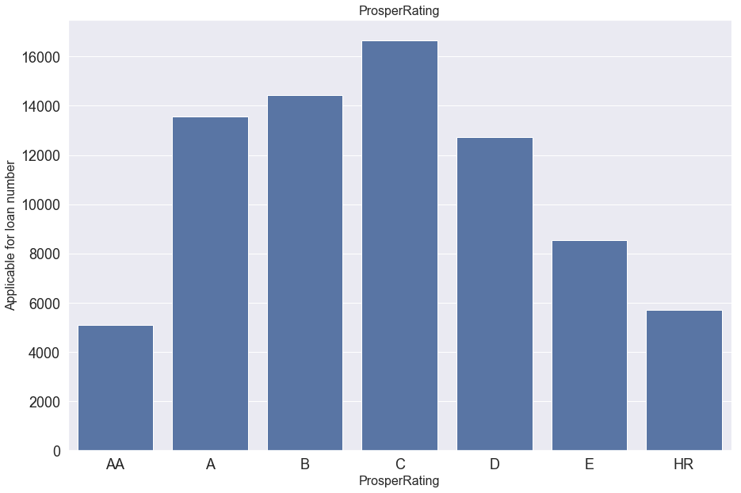

```python
#
p_rate_order = ['AA','A','B','C','D','E','HR']
base_color = sns.color_palette()[0]
plt.figure(figsize=(15,10))
sns.countplot(data = df, x = 'ProsperRating',order=p_rate_order, color = base_color)
plt.title('ProsperRating', fontsize=16)
plt.xlabel('ProsperRating', fontsize=16)
plt.ylabel('Applicable for loan number', fontsize=16)

plt.xticks(fontsize=18)
plt.yticks(fontsize=18);
```

> Most of the borrowers that Applicable for loan number has prosper rating of `C` at the time the listing was created.

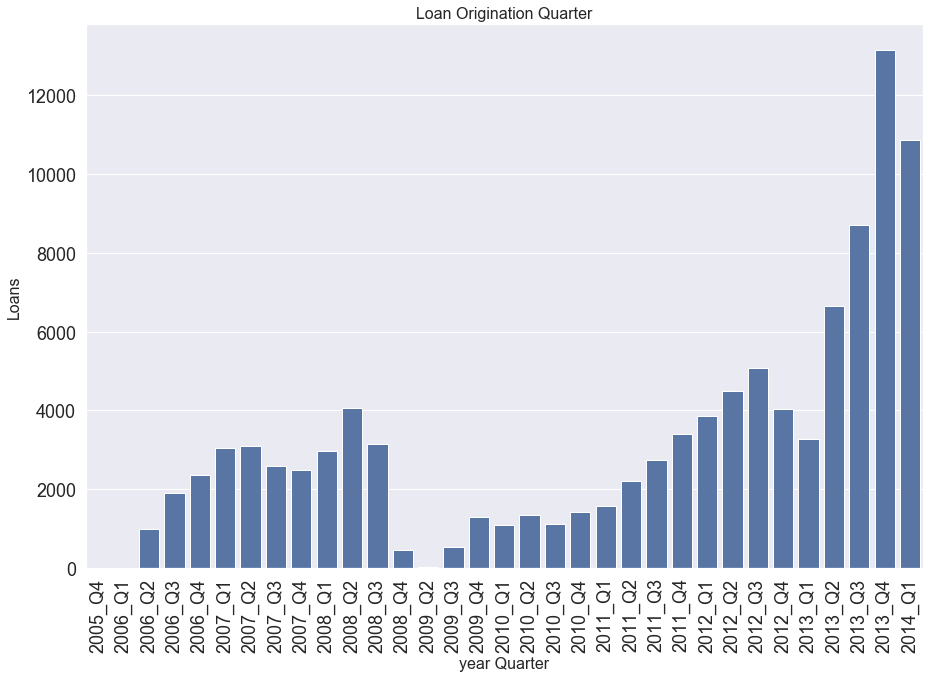

```python
base_color = sns.color_palette()[0]
plt.figure(figsize=(15,10))
sns.countplot(data = df, x = 'LoanOriginationQuarter', color = base_color,)
plt.title('Loan Origination Quarter', fontsize=16)
plt.ylabel('Loans', fontsize=16)
plt.xlabel('year Quarter', fontsize=16)
plt.xticks(rotation = 90,fontsize=18)
plt.yticks(fontsize=18);
```

As shown the number of loans increase from 2006 to 2008 a huge dip in the number of loans from Q4 2008 into 2009-10." that's because the economic and financial problem at 2008" for more info about it check [this](https://en.m.wikipedia.org/wiki/Financial_crisis_of_2007%E2%80%932008). then it starts to increase again from 2009 Q4 till 2012Q3 to make about 5000 loans then it duplicated from 2013Q2 and reached the maximum number if loans at the last quarter of 2013 with is 13000 loan.

```python
df.shape
```

```
(104009, 20)
```

[figure not shown]

```python
base_color = sns.color_palette()[0]
plt.figure(figsize=(10,10))
sns.countplot(data = df, x = 'LoanOriginationQuarterofyear', color = base_color)
plt.title('Loan Origination Quarter of years from 2010-2013', fontsize=16)
plt.xlabel('Loans', fontsize=16)
plt.ylabel('year Quarter', fontsize=16)
plt.xticks(fontsize=18)
plt.yticks(fontsize=18);
```

we can see that the most number of loans happend in the last queter of the year

```python
df['ListingCategory'].value_counts()
```

```
Debt Consolidation    54009
Not Available         16054
Other                  9489
Home Improvement       6916
Business               5181
Auto                   2359
Personal Loan          2271
Household Expenses     1779
Medical/Dental         1390
Large Purchases         794
Taxes                   785
Wedding Loans           724
Vacation                718
Student Use             605
Motorcycle              289
Engagement Ring         198
Baby&Adoption           188
Boat                     83
Cosmetic Procedure       82
RV                       50
Green Loans              45
Name: ListingCategory, dtype: int64
```

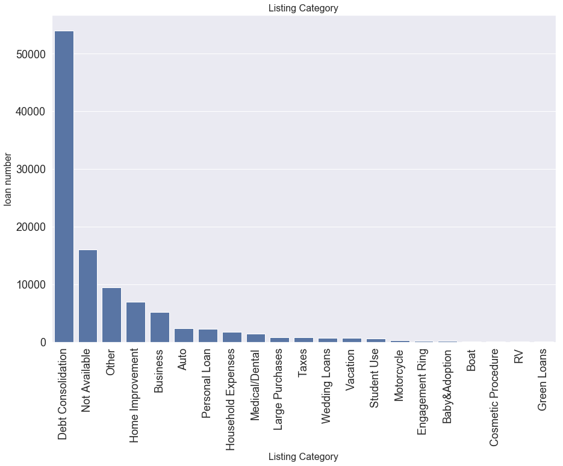

```python
ordered = df['ListingCategory'].value_counts().index
base_color = sns.color_palette()[0]
plt.figure(figsize=(15,10))
sns.countplot(data = df, x = 'ListingCategory',order=ordered , color = base_color)
plt.title('Listing Category', fontsize=16)
plt.xlabel('Listing Category', fontsize=16)
plt.ylabel('loan number', fontsize=16)

plt.xticks(rotation = 90,fontsize=18)
plt.yticks(fontsize=18);
```

```python
df['EmploymentStatus'].value_counts()
```

```
Employed         91731
Not available     6893
Other             3462
Self-employed     1092
Retired            735
Not employed        96
Part-time            0
Full-time            0
Name: EmploymentStatus, dtype: int64
```

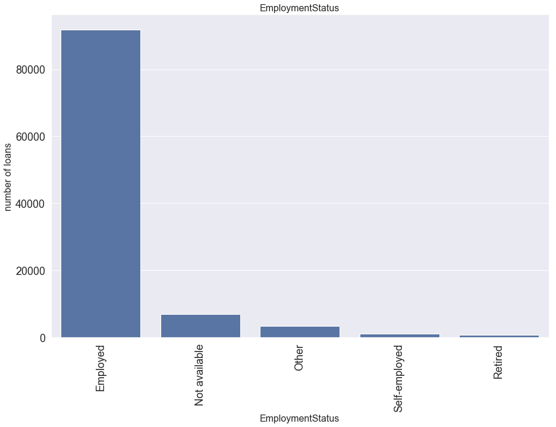

```python
ordered = df['EmploymentStatus'].value_counts()[:-3].index
base_color = sns.color_palette()[0]
plt.figure(figsize=(15,10))
sns.countplot(data = df, x = 'EmploymentStatus',order=ordered , color = base_color)
plt.title('EmploymentStatus', fontsize=16)
plt.xlabel('EmploymentStatus', fontsize=16)
plt.ylabel('number of loans', fontsize=16)

plt.xticks(rotation = 90,fontsize=18)
plt.yticks(fontsize=18);
```

the employed are the most people who take loans

```python
df['IncomeRange'].value_counts()
```

```
$25,000-49,999    29653
$50,000-74,999    29086
$100,000+         15941
$75,000-99,999    15890
Not displayed      7032
$1-24,999          6329
Not employed         78
Name: IncomeRange, dtype: int64
```

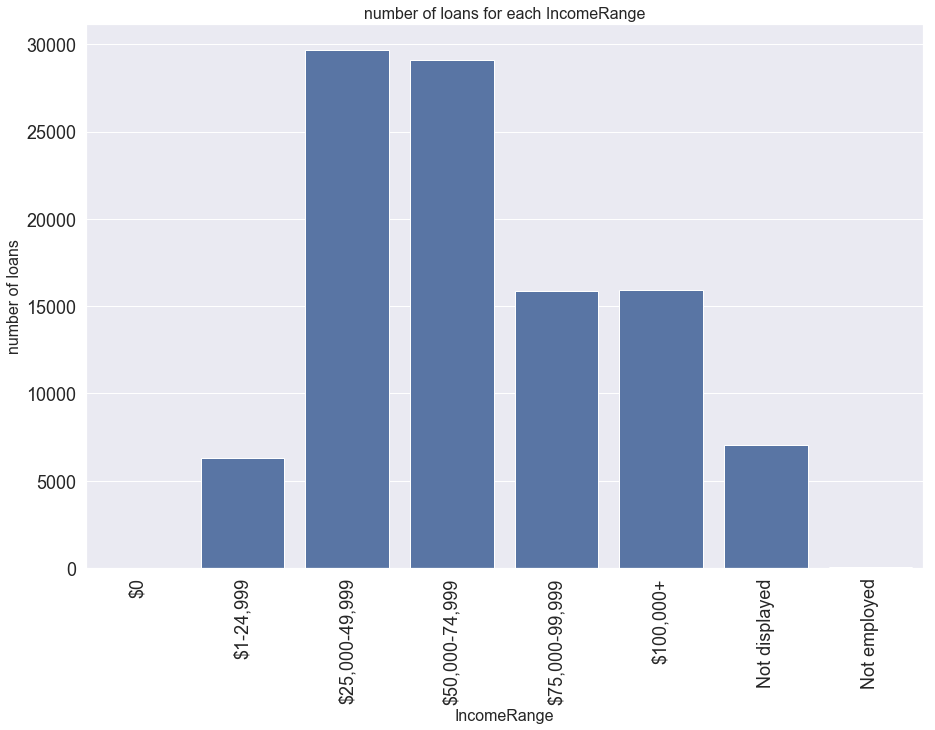

```python
base_color = sns.color_palette()[0]
plt.figure(figsize=(15,10))
sns.countplot(data = df, x = 'IncomeRange',order=['$0','$1-24,999','$25,000-49,999','$50,000-74,999','$75,000-99,999','$100,000+','Not displayed','Not employed'], color = base_color)
plt.title('number of loans for each IncomeRange', fontsize=16)
plt.xlabel('IncomeRange', fontsize=16)
plt.ylabel('number of loans', fontsize=16)

plt.xticks(rotation = 90,fontsize=18)
plt.yticks(fontsize=18);
```

> we can see that the number of people who takes a loan in `IncomeRange` of 25,000$ to 74,999$ but the people get higher income range get less number loans.

> but it may be hidden reasons of as the people who have high Income Range takes big loans. we'll see that in the next section .

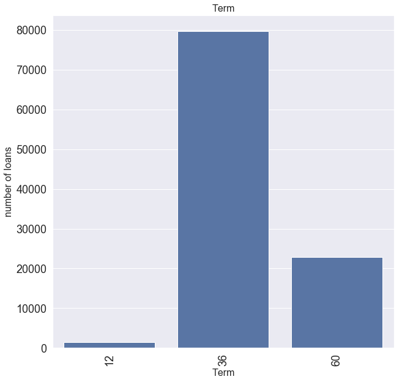

```python
base_color = sns.color_palette()[0]
plt.figure(figsize=(10,10))
sns.countplot(data = df, x = 'Term' , color = base_color)
plt.title('Term', fontsize=16)
plt.xlabel('Term', fontsize=16)
plt.ylabel('number of loans', fontsize=16)

plt.xticks(rotation = 90,fontsize=18)
plt.yticks(fontsize=18);
```

we can see the most number of loans in the middle term, wich is 36 mounths loan.

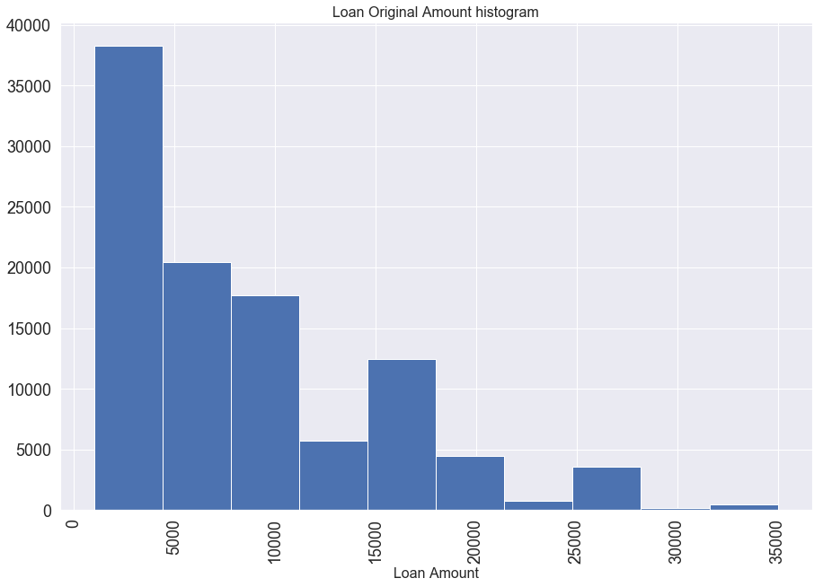

```python
ordered = df['ListingCategory'].value_counts().index
base_color = sns.color_palette()[0]
plt.figure(figsize=(15,10))
plt.hist(data = df, x = 'LoanOriginalAmount', color = base_color)
plt.title('Loan Original Amount histogram', fontsize=16)
plt.xlabel('Loan Amount', fontsize=16)


plt.xticks(rotation = 90,fontsize=18)
plt.yticks(fontsize=18);
```

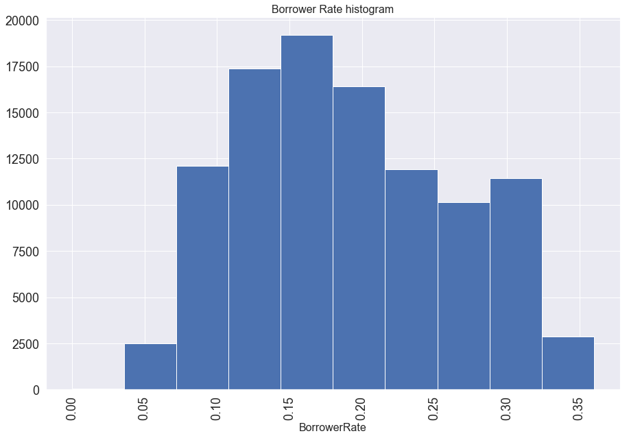

```python
ordered = df['BorrowerRate'].value_counts().index
base_color = sns.color_palette()[0]
plt.figure(figsize=(15,10))
plt.hist(data = df, x = 'BorrowerRate', color = base_color)
plt.title('Borrower Rate histogram', fontsize=16)
plt.xlabel('BorrowerRate', fontsize=16)


plt.xticks(rotation = 90,fontsize=18)
plt.yticks(fontsize=18);
```

```python
df.describe()
```

|  | Term | BorrowerRate | EstimatedLoss | EstimatedReturn | ProsperScore | DebtToIncomeRatio | LoanOriginalAmount | MonthlyLoanPayment | Investors | CreditScore |
| --- | --- | --- | --- | --- | --- | --- | --- | --- | --- | --- |
| count | 104009.000000 | 104009.000000 | 76768.000000 | 76768.000000 | 76768.000000 | 104009.000000 | 104009.000000 | 104009.000000 | 104009.00000 | 104009.000000 |
| mean | 40.945880 | 0.190880 | 0.078684 | 0.095453 | 6.065652 | 0.276759 | 8441.994683 | 274.449747 | 82.37166 | 694.201901 |
| std | 10.483937 | 0.074101 | 0.046019 | 0.029964 | 2.359486 | 0.554862 | 6330.649456 | 194.498481 | 105.40091 | 65.468364 |
| min | 12.000000 | 0.000000 | 0.004900 | -0.181600 | 1.000000 | 0.000000 | 1000.000000 | 0.000000 | 1.00000 | 9.500000 |
| 25% | 36.000000 | 0.132000 | 0.042400 | 0.074080 | 4.000000 | 0.140000 | 4000.000000 | 131.690000 | 2.00000 | 669.500000 |
| 50% | 36.000000 | 0.181100 | 0.069900 | 0.090660 | 6.000000 | 0.220000 | 6500.000000 | 220.160000 | 45.00000 | 689.500000 |
| 75% | 36.000000 | 0.249200 | 0.108000 | 0.115000 | 8.000000 | 0.320000 | 12000.000000 | 372.910000 | 118.00000 | 729.500000 |
| max | 60.000000 | 0.360000 | 0.366000 | 0.266700 | 11.000000 | 10.010000 | 35000.000000 | 2251.510000 | 1189.00000 | 889.500000 |

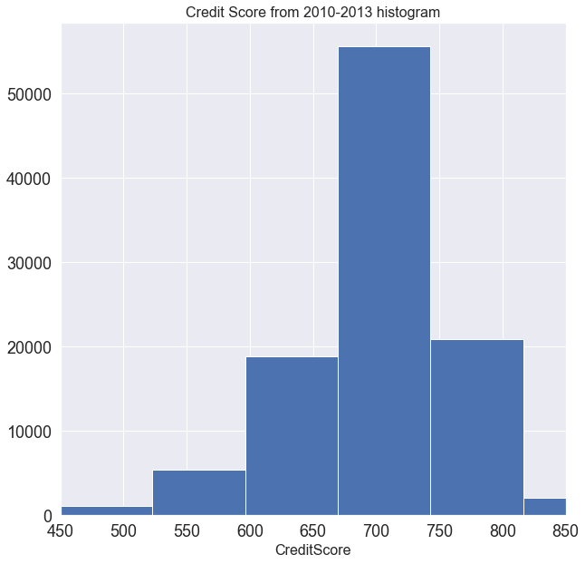

```python
base_color = sns.color_palette()[0]
plt.figure(figsize=(10,10))
plt.hist(data = df, x = 'CreditScore',bins=12, color = base_color)
plt.title('Credit Score from 2010-2013 histogram', fontsize=16)
plt.xlabel('CreditScore', fontsize=16)
plt.xlim(450, 850)

plt.xticks(fontsize=18)
plt.yticks(fontsize=18);
```

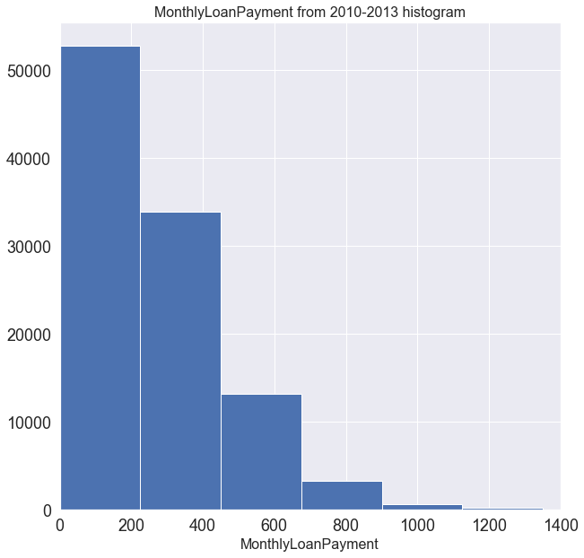

```python
base_color = sns.color_palette()[0]
plt.figure(figsize=(10,10))
plt.hist(data = df, x = 'MonthlyLoanPayment', color = base_color)
plt.title('MonthlyLoanPayment from 2010-2013 histogram', fontsize=16)
plt.xlabel('MonthlyLoanPayment', fontsize=16)
plt.xlim(0, 1400)
plt.xticks(fontsize=18)
plt.yticks(fontsize=18);
```

the most loans gets between 1-200 dollars per month then the number of loans decreases as it's monthly payment increase,tell it become 1400 dollars

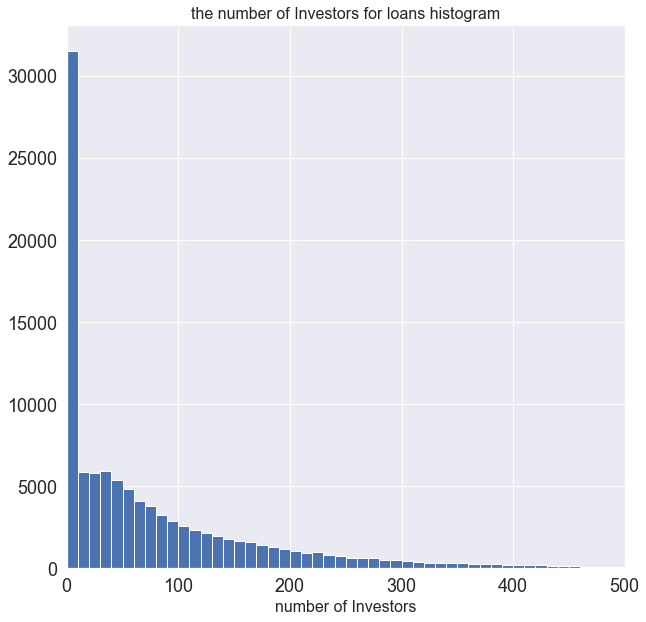

```python
bin_edges = np.arange(0, df['Investors'].max()+10, 10)
base_color = sns.color_palette()[0]
plt.figure(figsize=(10,10))
plt.hist(data = df, x = 'Investors', bins = bin_edges, color = base_color)
plt.title('the number of Investors for loans histogram', fontsize=16)
plt.xlabel('number of Investors', fontsize=16)
plt.xlim(0, 500)

plt.xticks(fontsize=18)
plt.yticks(fontsize=18);
```

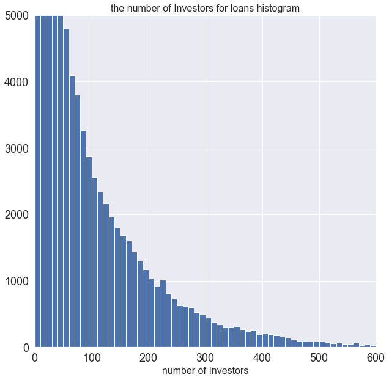

```python
# this is just zoom in into the data
bin_edges = np.arange(0, df['Investors'].max()+10, 10)
base_color = sns.color_palette()[0]
plt.figure(figsize=(10,10))
plt.hist(data = df, x = 'Investors', bins = bin_edges, color = base_color)
plt.title('the number of Investors for loans histogram', fontsize=16)
plt.xlabel('number of Investors', fontsize=16)
plt.xlim(0, 600)
plt.ylim(0,5000)
plt.xticks(fontsize=18)
plt.yticks(fontsize=18);
```

the number of investors decreases and the most loan have between 1-10 investor

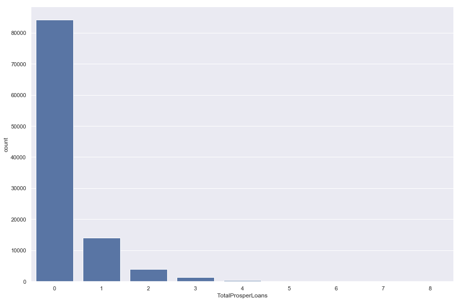

```python
default_color = sns.color_palette()[0]
plt.figure(figsize=(15,10))
ax = sns.countplot(df['TotalProsperLoans'], color=default_color)
plt.show()
```

A significant number of borrowers are on their first loan with Prosper at the time of listing, then the second or third loan

### Discuss the distribution(s) of your variable(s) of interest. Were there any unusual points? Did you need to perform any transformations?

> The brrow rate was normally distribution and the amunt of loan is right skewed, no i didn't.

### Of the features you investigated, were there any unusual distributions? Did you perform any operations on the data to tidy, adjust, or change the form of the data? If so, why did you do this?

> yes, to make it eaiser to get the information from only one column. and the changes shown in the accessing part

## Bivariate Exploration

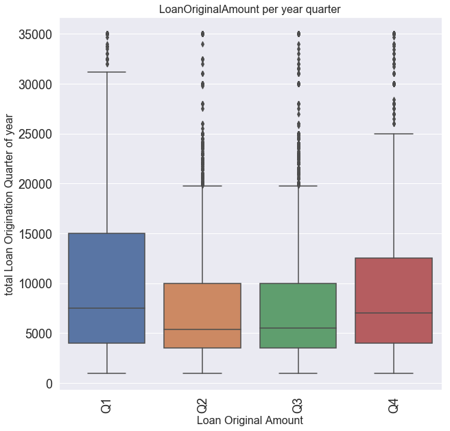

```python
# the relation between LoanOriginalAmount and the LoanOriginationQuarterofyear
plt.figure(figsize=(10,10))
ax = sns.boxplot(data=df, y='LoanOriginalAmount', x='LoanOriginationQuarterofyear')
plt.title('LoanOriginalAmount per year quarter', fontsize=16)
plt.xlabel('Loan Original Amount', fontsize=16)
plt.ylabel('total Loan Origination Quarter of year', fontsize=16)
plt.xticks(rotation = 90,fontsize=18)
plt.yticks(fontsize=18);
```

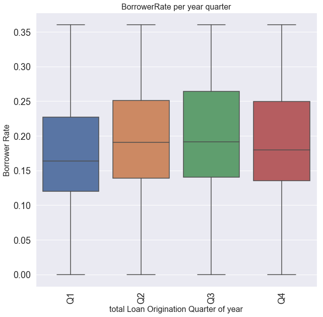

```python
# the relation between the quater of the year and the borrowerRate

plt.figure(figsize=(10,10))
ax = sns.boxplot(data=df, y='BorrowerRate', x='LoanOriginationQuarterofyear')
plt.title('BorrowerRate per year quarter', fontsize=16)
plt.ylabel('Borrower Rate', fontsize=16)
plt.xlabel('total Loan Origination Quarter of year', fontsize=16)

plt.xticks(rotation = 90,fontsize=18)
plt.yticks(fontsize=18);
```

we can see that accourding to the median of the data we can see the lowest median is in Q1 and the heighest in the Q2 and Q3 and That show the reason of decreasing the orginal amount

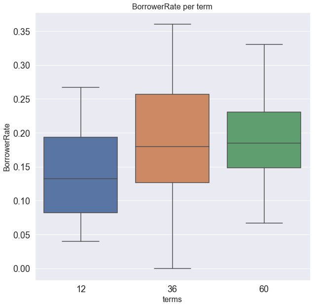

```python
# the relation between the term and the borrowerRate

plt.figure(figsize=(10,10))
ax = sns.boxplot(data=df, x='Term', y='BorrowerRate')
plt.title('BorrowerRate per term', fontsize=16)
plt.xlabel('terms', fontsize=16)
plt.ylabel('BorrowerRate', fontsize=16)
plt.xticks(fontsize=18)
plt.yticks(fontsize=18);
```

even the borrowerRate increases most of loans are 36 or 60 terms

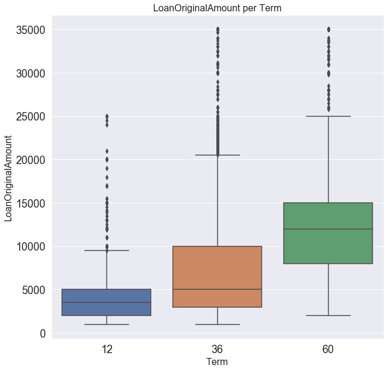

```python
# the relation between the term and the LoanOriginalAmount

plt.figure(figsize=(10,10))
ax = sns.boxplot(data=df, y='LoanOriginalAmount', x='Term')
plt.title('LoanOriginalAmount per Term', fontsize=16)
plt.xlabel('Term', fontsize=16)
plt.ylabel('LoanOriginalAmount', fontsize=16)
plt.xticks(fontsize=18)
plt.yticks(fontsize=18);
```

the amount of the loan increase on the long term

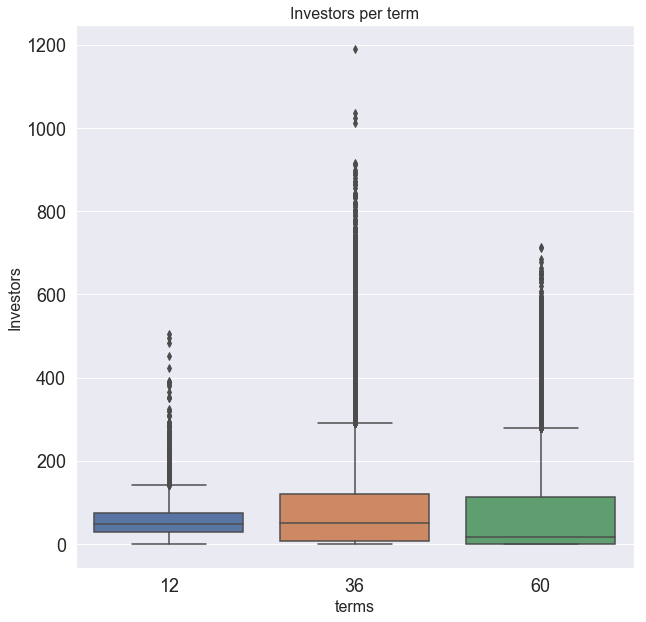

```python
# the relation between the term and number of Investors

plt.figure(figsize=(10,10))
ax = sns.boxplot(data=df, x='Term', y='Investors')
plt.title('Investors per term', fontsize=16)
plt.xlabel('terms', fontsize=16)
plt.ylabel('Investors', fontsize=16)
plt.xticks(fontsize=18)
plt.yticks(fontsize=18);
```

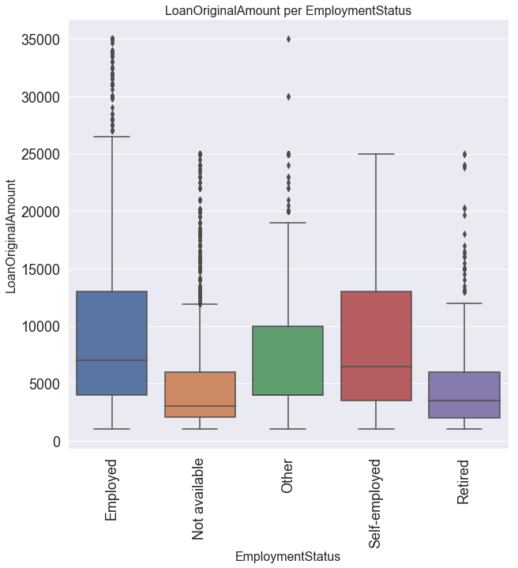

```python
# the relation between the Employment Status and number of Loan Original Amount

ordered = df['EmploymentStatus'].value_counts()[:-3].index
plt.figure(figsize=(10,10))
ax = sns.boxplot(data=df, y='LoanOriginalAmount', x='EmploymentStatus', order=ordered)
plt.title('LoanOriginalAmount per EmploymentStatus', fontsize=16)
plt.xlabel('EmploymentStatus', fontsize=16)
plt.ylabel('LoanOriginalAmount', fontsize=16)
plt.xticks(rotation = 90,fontsize=18)
plt.yticks(fontsize=18);
```

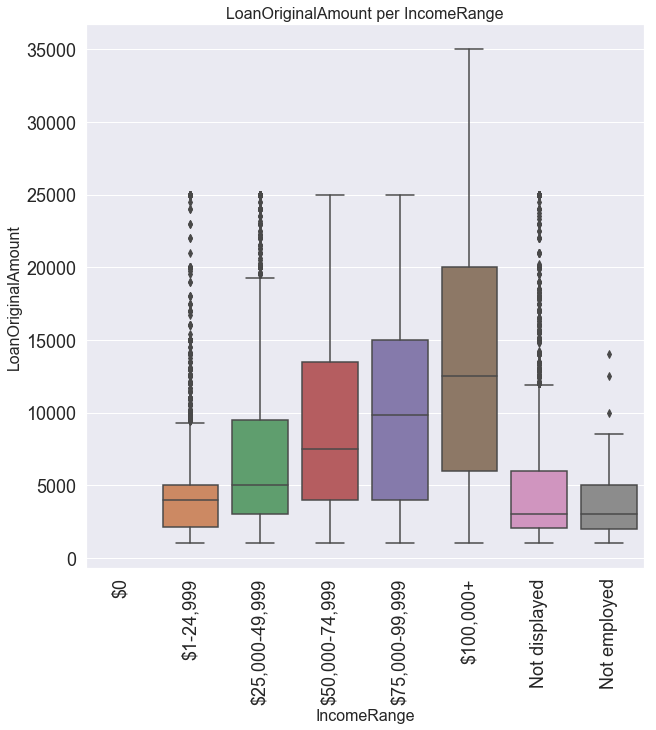

```python
# the relation between the Employment Status and number of Loan Original Amount

ordered = ['$0','$1-24,999','$25,000-49,999','$50,000-74,999','$75,000-99,999','$100,000+','Not displayed','Not employed']
plt.figure(figsize=(10,10))
ax = sns.boxplot(data=df, y='LoanOriginalAmount', x='IncomeRange', order=ordered)
plt.title('LoanOriginalAmount per IncomeRange', fontsize=16)
plt.xlabel('IncomeRange', fontsize=16)
plt.ylabel('LoanOriginalAmount', fontsize=16)
plt.xticks(rotation = 90,fontsize=18)
plt.yticks(fontsize=18);
```

as the salary increases the amount of loan increases

it shows that the number the most spread loan amount is for Employed and the Self-employed people and the are approximately the same medians

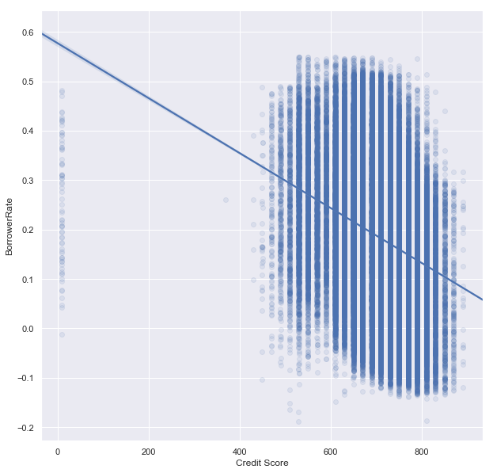

```python
# the relation between the CreditScore and BorrowerRate
plt.figure(figsize = [10, 10])
sns.regplot(data = df,x_jitter = 0.2, y_jitter = 0.2, x = 'CreditScore', y = 'BorrowerRate',scatter_kws = {'alpha' : 1/10})
plt.xlabel('Credit Score')
plt.ylabel('BorrowerRate')
plt.show()
```

it shows that these are reverse relation between the CreditScore and BorrowerRate

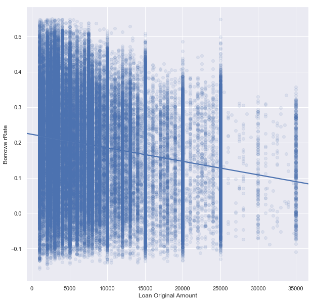

```python
# the relation between the LoanOriginalAmount and BorrowerRate
plt.figure(figsize = [10, 10])
sns.regplot(data = df,x_jitter = 0.2, y_jitter = 0.2, x = 'LoanOriginalAmount', y = 'BorrowerRate',scatter_kws = {'alpha' : 1/10})
plt.xlabel('Loan Original Amount')
plt.ylabel('Borrowe rRate')
plt.show()
```

it shows there's an inverse proportion between LoanOriginalAmount and BorrowerRate

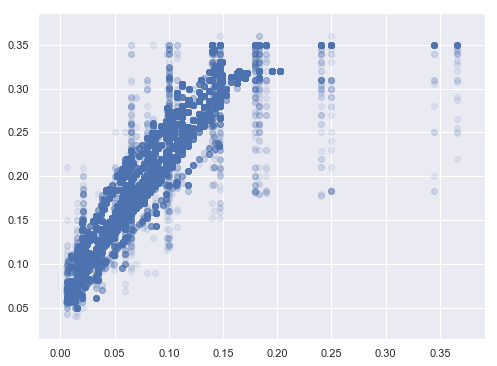

```python
plt.figure(figsize = [8, 6])
plt.scatter(data = df, x = 'EstimatedLoss', y = 'BorrowerRate', alpha = 1/10)

plt.show()
```

### Did you observe any interesting relationships between the other features (not the main feature(s) of interest)?

> It was seen that borrowers with income range of \$100,000+ take huge amounts of loans compared to the other borrower.

strong postive correlation between EstimatedLoss and BorrowerRate

## Multivariate Exploration

[figure not shown]

```python
numeric_vars = ['BorrowerRate', 'EstimatedLoss', 'EstimatedReturn', 'ProsperScore', 'DebtToIncomeRatio', 'CreditScore','LoanOriginalAmount' ,'TotalProsperLoans', 'MonthlyLoanPayment']
categoric_vars = ['Term', 'ProsperRating','LoanOriginationQuarterofyear','IncomeRange']

# correlation plot
plt.figure(figsize = [8, 5])
sns.heatmap(df[numeric_vars].corr(), annot = True, fmt = '.3f',
           cmap = 'vlag_r', center = 0)
plt.show()
```

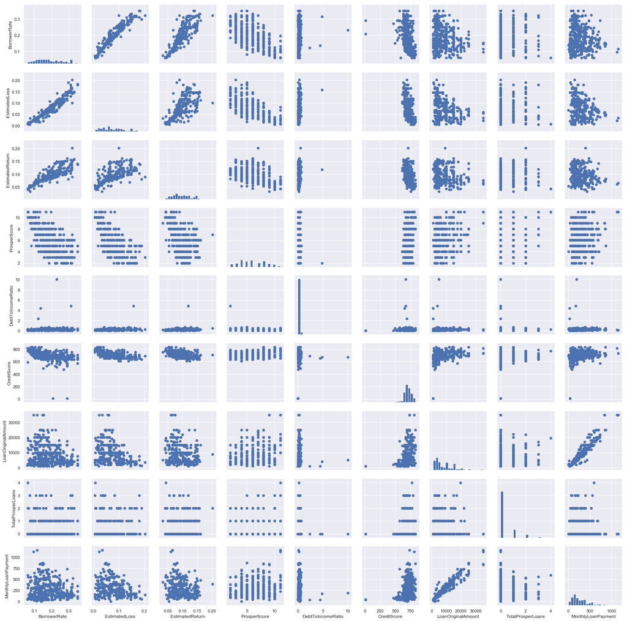

```python
# plot matrix: sample 500 diamonds so that plots are clearer and
# they render faster
samples = np.random.choice(df.shape[0], 500, replace = False)
df_samp = df.loc[samples,:]

g = sns.PairGrid(data = df_samp, vars = numeric_vars)
g = g.map_diag(plt.hist, bins = 20);
g.map_offdiag(plt.scatter);
```

As expected, t 'EstimatedLoss' and 'EstimatedReturn' dimensions are all highly correlated with one another, and all of them are also highly correlated with 'BorrowerRate' Since BorrowerRate is a measure of loan cost, it's not too surprising that the overall trend between BorrowerRate and the two individual estimations.

Let's move on to looking at how BorrowerRate and EstimatedLoss weight correlate with the categorical variables.

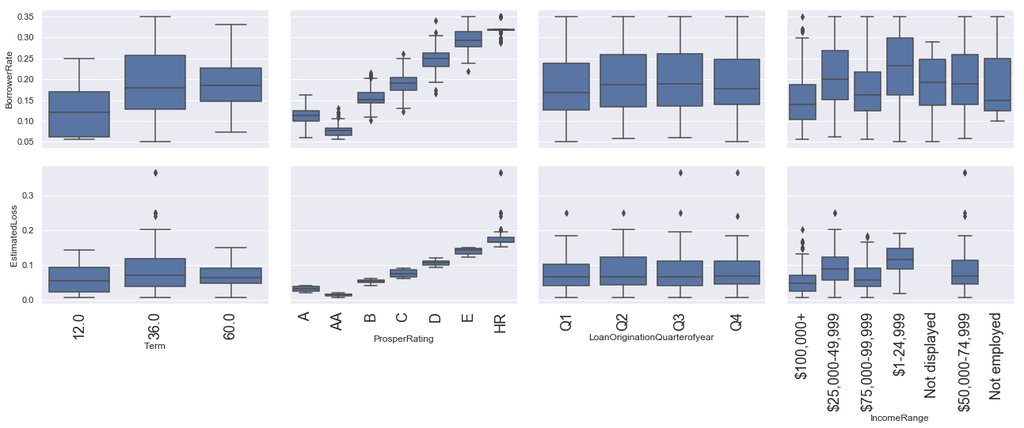

```python
samples = np.random.choice(df.shape[0], 2000, replace = False)
df_samp = df.loc[samples,:]

def boxgrid(x, y, **kwargs):
    """ Quick hack for creating box plots with seaborn's PairGrid. """
    default_color = sns.color_palette()[0]
    sns.boxplot(x, y, color = default_color)
    plt.xticks(rotation = 90,fontsize=18)
plt.figure(figsize = [10, 10])
g = sns.PairGrid(data = df_samp, y_vars = ['BorrowerRate', 'EstimatedLoss'], x_vars = categoric_vars,
                height = 3, aspect = 1.5)
g.map(boxgrid)
plt.show();
```

Interestingly, it appears that there are some postive relationships between the categorical variables and the two numeric variables of interest. The loan with the highest features (propserRatting HR, term 36, in the Q3 of the year, for customers(brorrwer) income range 1-24,999 dollars) seem to get the highest cost of the loan.

the best loan cost features (propserRatting AA, term 12, in the Q1 of the year, for customers(brorrwer) income +100,000 USD) seem to get the Lowest cost of the loan.

Finally, let's look at relationships between the four categorical features.

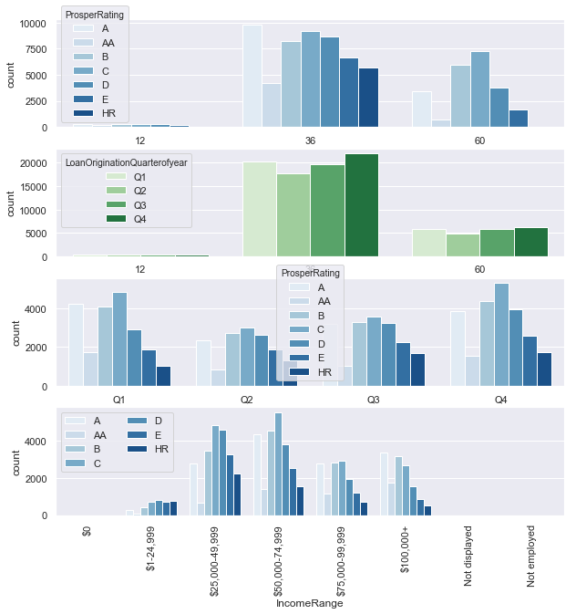

```python
# since there's only three subplots to create, using the full data should be fine.
plt.figure(figsize = [10, 10])
p_rate_order = ['AA','A','B','C','D','E','HR']

# subplot 1: Term vs ProsperRating
plt.subplot(4, 1, 1)
sns.countplot(data = df, x = 'Term', hue = 'ProsperRating', palette = 'Blues')

# subplot 2: Term vs ProsperRating
plt.subplot(4, 1, 2)
sns.countplot(data = df, x = 'Term', hue = 'LoanOriginationQuarterofyear', palette = 'Greens')

# subplot 3: Term vs ProsperRating
plt.subplot(4, 1, 3)
sns.countplot(data = df, x = 'LoanOriginationQuarterofyear', hue = 'ProsperRating', palette = 'Blues')

ir_order =['$0','$1-24,999','$25,000-49,999','$50,000-74,999','$75,000-99,999','$100,000+','Not displayed','Not employed']
# subplot 4: LoanStatus vs. ProsperRating
ax = plt.subplot(4, 1, 4)
sns.countplot(data = df, x = 'IncomeRange', hue = 'ProsperRating', order=ir_order, palette = 'Blues')
ax.legend(ncol = 2) # re-arrange legend to reduce overlapping

plt.xticks(rotation = 90)

plt.show()
```

```python
# compute the logarithm of EstimatedLoss to make multivariate plotting easier
def log_trans(x, inverse = False):
    """ quick function for computing log and power operations """
    if not inverse:
        return np.log10(x)
    else:
        return np.power(10, x)

df['log_EstimatedLoss'] = df['EstimatedLoss'].apply(log_trans)
```

```python
# compute the cuberoot of BorrowerRate to make multivariate plotting easier
def cuberoot_trans(x, inverse = False):
    """ quick function for computing cube root and cube operations """
    if not inverse:
        return x ** (1/3)
    else:
        return x ** 3
df['cr_borrower_rate'] = df['BorrowerRate'].apply(cuberoot_trans)
```

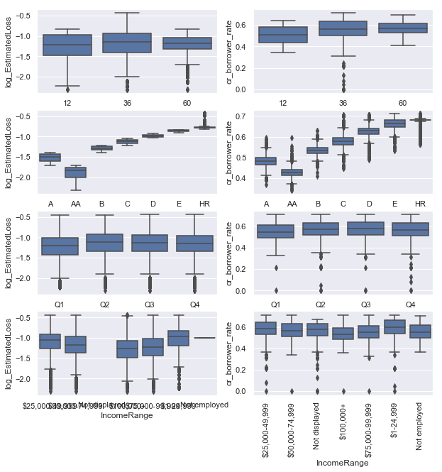

```python
# plot the categorical variables against price and carat again, this time
# with full data and variable transforms
fig, ax = plt.subplots(ncols = 2, nrows = 4 , figsize = [10,10])
default_color = sns.color_palette()[0]

for i in range(len(categoric_vars)):
    var = categoric_vars[i]
    sns.boxplot(data = df, x = var, y = 'log_EstimatedLoss', ax = ax[i,0],
               color = default_color)
    plt.xticks(rotation = 90)

    sns.boxplot(data = df, x = var, y = 'cr_borrower_rate', ax = ax[i,1],
               color = default_color)
    plt.xticks(rotation = 90)


plt.show()
```

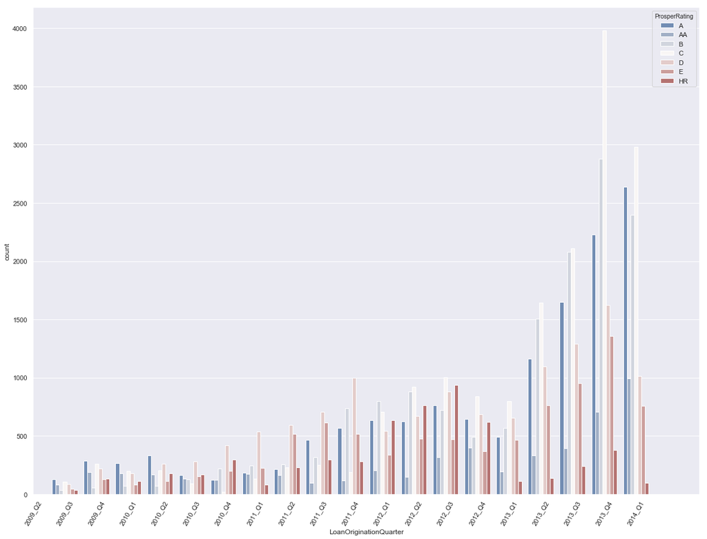

```python
# Zoom in on the required region
plt.figure(figsize=(20,15))
ax = sns.countplot(data=df, x='LoanOriginationQuarter', hue='ProsperRating', palette = 'vlag')
plt.xticks(rotation=60)
# because the ProsperRating is for loans after 2009(Q4*3)
plt.xlim(13, 34)
plt.show()
```

### Talk about some of the relationships you observed in this part of the investigation. Were there features that strengthened each other in terms of looking at your feature(s) of interest?

> As expected, t 'EstimatedLoss' and 'EstimatedReturn' dimensions are all highly correlated with one another, and all of them are also highly correlated with 'BorrowerRate' Since BorrowerRate is a measure of loan cost, it's not too surprising that the overall trend between BorrowerRate and the two individual estimations.

> the best loan cost features (propserRatting AA, term 12, in the Q1 of the year, for customers(brorrwer) income +100,000 USD) seem to get the Lowest cost of the loan.

### Were there any interesting or surprising interactions between features?

> The most interesting feature for me was Prosper Rating , it was so surpising that the people with the highest rate "AA" take much lower number of loans then in the middle class "C"

```python
# saving the data fram to csv file to use in slide_deck
df.to_csv('clean_loan.csv', index=False)
```